Neural Networks and Generative Aversarial Networks (GANs)

A Portfolio Project

Author: Brock Frary  
Published: 2026-01-06  
Revised: 2026-01-09

# **Introduction**

## Overview

This notebook is a portfolio project to demonstrate competency in creating an Artificial Neural Network (ANN) and a Generative Adversarial Network (GAN).

This project has built practical deep learning skills by training neural networks to recognize handwritten digits from the Modified National Institute of Standards and Technology (MNIST) dataset (28×28 grayscale images of digits 0–9). The MNIST dataset is often considered the "hello world" of deep learning because it’s small enough to run quickly, but rich enough to demonstrate the full end-to-end workflow: **data preparation → model design → training → evaluation → improvement**.

### **What I have learned**

- **Install and verify** a working deep learning environment (TensorFlow + Keras), then confirm success by printing version numbers.
- Build models using the **Keras Sequential Application Programming Interface (API)** (a straightforward "stack of layers" approach), then understand when more advanced styles like the Functional API and model subclassing are useful.
- Train two common architectures for digit recognition:
  - A **Multi-Layer Perceptron (MLP)** classifier using flattened pixel inputs (784 features) plus regularization (Dropout).
  - A **Convolutional Neural Network (CNN)** (Conv2D → Pooling → Flatten → Dense) that learns spatial features like edges and strokes—often the better choice for image problems.
- Evaluate beyond accuracy using **precision/recall/F1** and **confusion matrices** to see *which digits* are most often misclassified and why.
- Improve training stability and generalization using **callbacks** such as EarlyStopping, learning-rate scheduling, and checkpointing.

### **Why this matters (business context)**

Digit recognition is a simplified version of real business Optical Character Recognition (OCR) and image classification tasks (e.g., reading form fields, processing scanned documents, validating handwritten inputs). The same workflow you practice here—**data preprocessing, model selection, evaluation by class, and performance tuning**—directly maps to production use cases where mistakes create cost (rework, manual review, customer friction) and strong performance creates leverage (speed, automation, scalability). Keras is widely used in real systems because it combines a readable developer experience with TensorFlow’s production-grade performance.

### **Notes**

- This project is independent of my UT Austin AI/ML course I am currently enrolled in. However, it is this week's topic of discussion (2025/01/10).
- This project was initially based on AI Academy's YouTube video shown in the Reference section; see the Appendix for study notes taken on the presentation. Many thanks to AI Academy on YouTube for the excellent learning material.

#### **Reference:**

Keras Mastery Tutorial: From Beginner to Building AI Models with TensorFlow/Keras!

AI Academy, YouTube

Retrieved: 2025-01-06

https://youtu.be/ozBQiXAnGFQ?si=mCvtP6b_pnbcmG7r

# **Install Dependencies**

`!pip` — Runs the pip package installer from inside a Jupyter/Colab notebook cell (the `!` means "run a shell command").

`install` — Tells pip to download and install the listed packages (and any required dependencies).

`-q` — "Quiet" mode: reduces output/log noise during installation.

## Packages being installed:

- `tensorflow` — Deep learning framework for building/training neural networks (commonly used for MNIST).
- `numpy` — Core library for fast numerical arrays and math operations.
- `pandas` — Data analysis library for structured data (tables/DataFrames), cleaning, and reporting.
- `matplotlib` — Standard Python library for plotting charts/figures.
- `seaborn` — High-level statistical plotting library built on matplotlib (often used for heatmaps/confusion matrices).
- `scikit-learn` — Machine learning utilities (e.g., metrics like confusion matrix, train/test split, preprocessing).

```python
!pip install -q tensorflow numpy matplotlib seaborn scikit-learn pandas
```

## **Configure and Verify Environment**

```python
# ===============================================================
# Imports + Environment Sanity Check (Versions)
# ===============================================================
# Goal:
# - Import all major libraries used in this notebook
# - Print version numbers so you can confirm the runtime is configured correctly
#   (this is especially helpful in Colab where environments can change)

# Import libraries
import sys                      # Standard library: access Python runtime info (e.g., Python version)
import numpy as np              # Numerical arrays + math operations (core ML dependency)
import tensorflow as tf         # Deep learning framework (runs the neural network training)
from tensorflow import keras    # High-level neural network API (builds models/layers on top of TensorFlow)
import matplotlib.pyplot as plt # Plotting library (charts, graphs, learning curves)
import seaborn as sns           # Higher-level visualization library (heatmaps, prettier statistical plots)
import sklearn                  # Machine learning utilities (metrics, preprocessing, model evaluation tools)
import pandas as pd             # Data tables (DataFrames), reporting, and clean tabular summaries
import os                       # Standard library: file/path operations (e.g., check if checkpoint exists)
import random                   # Standard library: Python RNG (seed control for reproducibility)
import platform                 # Standard library: runtime/OS details for compute context reporting
import time                     # Standard library: precise timing (measure training duration, sec/epoch)
from IPython.display import display  # Jupyter utility: rich display for DataFrames/objects (portable vs implicit display())

# Sanity check
# Purpose:
# - Confirm your notebook is running the expected software versions.
# - This prevents "it worked yesterday" issues when versions update or differ across machines.
print("\n---------------------------------------------------------------")
print("Runtime / Platform")
print("---------------------------------------------------------------")

# Kernel version
print(f"Platform:              {platform.platform()}")

# Python version:
# - Displays the major.minor.patch version (example: 3.10.12)
# - Using split()[0] keeps the output clean (no build/compiler details)
print(f"Python version:        {sys.version.split()[0]}")

# NumPy version:
# - Critical for array operations, reshaping, normalization, and math
print(f"NumPy version:         {np.__version__}")

# TensorFlow version:
# - Drives model training, GPU acceleration (if available), and backend execution
print(f"TensorFlow version:    {tf.__version__}")

# Keras version:
# - Keras is typically bundled inside TensorFlow in modern setups, but still has its own version
print(f"Keras version:         {keras.__version__}")

# Matplotlib version:
# - Used for all charts (training curves, distributions, etc.)
print(f"Matplotlib version:    {plt.matplotlib.__version__}")

# Seaborn version:
# - Used for advanced plots like confusion matrix heatmaps
print(f"Seaborn version:       {sns.__version__}")

# Scikit-learn version:
# - Used for evaluation metrics like confusion_matrix and classification_report
print(f"Scikit-learn version:  {sklearn.__version__}")


# ===============================================================
# Reproducibility + Compute Context (Seeds + Runtime Info)
# ===============================================================
# Goal:
# - Set random seeds (Python, NumPy, TensorFlow) for repeatability
# - Print compute context (CPU vs GPU visibility) for portfolio-grade documentation
# - Provide best-effort determinism notes (without breaking the notebook)
#
# Guard-Rails:
# - Additive-only: does not modify model definitions or data pipelines.
# - Determinism in TF can be hardware/version dependent; we record what we can observe.
# ===============================================================

# -----------------------------
# 1) Reproducibility Seed
# -----------------------------
SEED = 42

# Best-practice: seed Python, NumPy, and TensorFlow.
# NOTE:
# - Some determinism behaviors may require setting environment variables BEFORE TF loads.
# - In notebooks, TF is often imported earlier, so this is "best effort" and still valuable.
random.seed(SEED)
np.random.seed(SEED)
tf.random.set_seed(SEED)

# TF convenience (if available in your TF version):
# - Sets Python, NumPy, and TF seeds in one call (still safe even if we already set them)
try:
    tf.keras.utils.set_random_seed(SEED)
except Exception:
    # Safe fallback: not all TF versions expose this utility the same way
    pass

# Display Seed information
print("\n---------------------------------------------------------------")
print("Display Seed")
print("---------------------------------------------------------------")
print(f"Seed (SEED):                     {SEED}")

# Detect GPU availability from TensorFlow
gpus = tf.config.list_physical_devices('GPU')
cpus = tf.config.list_physical_devices('CPU')

print("\n---------------------------------------------------------------")
print("TensorFlow Device Visibility")
print("---------------------------------------------------------------")
print(f"CPU devices visible:              {len(cpus)}")
print(f"GPU devices visible:              {len(gpus)}")

if len(gpus) > 0:
    print("\nGPU Details:")
    for i, gpu in enumerate(gpus):
        print(f"  GPU[{i}]:                        {gpu.name}")
else:
    print("\nGPU Details:")
    print("  No GPU detected by TensorFlow (training will run on CPU).")

# -----------------------------
# 3) Training Timing Notes (set up variables)
# -----------------------------
# These variables are used by the training timing patches added in later steps.
# They are defined here so the notebook has a single place that "owns" timing configuration.
TRAINING_TIME_ENABLED = True

print("\n---------------------------------------------------------------")
print("Training Timing")
print("---------------------------------------------------------------")
print(f"Timing enabled:                   {TRAINING_TIME_ENABLED}")
print("Timing will be reported as: total seconds + seconds/epoch (where available).")
```

```
---------------------------------------------------------------
Runtime / Platform
---------------------------------------------------------------
Platform:              Linux-6.6.105+-x86_64-with-glibc2.35
Python version:        3.12.12
NumPy version:         2.0.2
TensorFlow version:    2.19.0
Keras version:         3.10.0
Matplotlib version:    3.10.0
Seaborn version:       0.13.2
Scikit-learn version:  1.6.1

---------------------------------------------------------------
Display Seed
---------------------------------------------------------------
Seed (SEED):                     42

---------------------------------------------------------------
TensorFlow Device Visibility
---------------------------------------------------------------
CPU devices visible:              1
GPU devices visible:              0

GPU Details:
  No GPU detected by TensorFlow (training will run on CPU).

---------------------------------------------------------------
Training Timing
---------------------------------------------------------------
Timing enabled:                   True
Timing will be reported as: total seconds + seconds/epoch (where available).
```

```python
# ===============================================================
# Load + Preprocess MNIST (Images + Labels)
# ===============================================================
# Goal:
# - Load the MNIST dataset (handwritten digits 0–9)
# - Prepare the images and labels in the correct format for a CNN
# - Apply normalization so training is faster and more stable

# Load the famous MNIST dataset
from tensorflow.keras.datasets import mnist         # Built-in MNIST loader (downloads if needed)
from tensorflow.keras.utils import to_categorical   # Converts integer labels into one-hot vectors

# Load and split data
# Purpose:
# - MNIST comes pre-split into training and test sets:
#   - Training set: used to learn model weights
#   - Test set: used for final evaluation (unseen during training)
(x_train, y_train), (x_test, y_test) = mnist.load_data()

# Reshape: 60,000 images of 28x28 -> 60,000 images of 28x28x1
# Purpose:
# - Original MNIST images load as 2D arrays: (28, 28)
# - CNN layers (Conv2D) expect a channel dimension, even for grayscale images:
#     (28, 28, 1)
# - reshape(-1, 28, 28, 1) means:
#     - "-1" lets NumPy automatically infer the number of images (e.g., 60000 / 10000)
#     - each image becomes 28x28 with 1 channel
# - Dividing by 255.0 normalizes pixel values:
#     - original: 0 to 255
#     - normalized: 0.0 to 1.0
#   This improves training stability and helps the optimizer converge faster.
x_train = x_train.reshape(-1, 28, 28, 1) / 255.0  # Normalize 0-255 -> 0-1
x_test = x_test.reshape(-1, 28, 28, 1) / 255.0

# Convert labels:  3 -> [0,0,0,1,0,0,0,0,0,0]
# Purpose:
# - MNIST labels load as integers (0–9), for example: 3
# - to_categorical converts them to one-hot vectors length 10:
#     3 -> [0,0,0,1,0,0,0,0,0,0]
# - One-hot labels are required when using:
#     loss='categorical_crossentropy'
# - This matches the model output layer:
#     Dense(10, activation='softmax')
y_train = to_categorical(y_train, 10)       # One-hot encoding
y_test = to_categorical(y_test, 10)
```

## Reproducibility + Compute Context

Purpose: To make results repeatable and defensible, we explicitly document:

1. Reproducibility Controls
   - Random seeds (Python, NumPy, TensorFlow)
   - Determinism guard-rails (best effort)
   - Why this matters: the same notebook should produce comparable results across runs
2. Compute Context
   - Whether training runs on CPU or GPU
   - What devices TensorFlow can see
   - Why this matters: training speed, model iteration time, and performance can differ meaningfully across CPU/GPU runtimes.
3. Training Time Reporting
   - Total training time and average seconds/epoch are measured for MLP and CNN training.
   - Why this matters: portfolio reviewers want to see you understand the operational side of ML (cost, iteration speed, and repeatability), not just accuracy.

Notes / Guard-Rails:

- These additions are additive-only and do NOT change model architectures.
- Determinism in deep learning is "best effort" and can vary by GPU kernels and versions.
- We still set seeds and record compute context to provide a professional baseline.

# **Step-by-Step Model Building**

## Building the Model

### Workflow A: MLP (Dense Network) — Flattened Images

This section builds a **basic Dense neural network** (MLP) that expects **flattened MNIST images**.

Guard-rails (VERY IMPORTANT):

- **Input shape:** MLP expects **(784,)** per image (28×28 flattened).
- **Label format + loss pairing:**
  - Integer labels (e.g., `5`) → use **`sparse_categorical_crossentropy`**
  - One-hot labels (e.g., `[0,0,0,0,0,1,0,0,0,0]`) → use **`categorical_crossentropy`**
- If you run the CNN workflow later, it uses **(28,28,1)** inputs and typically **one-hot labels** (different pipeline).

```python
# ===============================================================
# Model Build (MLP / Dense Neural Network) + Compile Settings
# ===============================================================
# Goal:
# - Define a simple fully-connected neural network (MLP) for MNIST-style digit classification
# - This version assumes the images will be provided as 784-length vectors (28x28 flattened)

# Step 1: Import what we need
from tensorflow.keras.models import Sequential
from tensorflow.keras.layers import Dense, Dropout, Input, Conv2D, MaxPooling2D, Flatten

# Note:
# - In this specific MLP model, only Input, Dense, and Dropout are actually used.
# - Conv2D / MaxPooling2D / Flatten are CNN layers and are imported here for convenience/consistency.

# Step 2: Build the network layer by layer
mlp_model = Sequential([
    # Input
    # Purpose:
    # - Defines the expected shape of a single training example.
    # - (784,) corresponds to a flattened 28x28 image (28*28 = 784).
    Input(shape=(784,)),

    # First Hidden Layer
    # Purpose:
    # - Learns a set of higher-level features from the raw pixel inputs.
    # - 128 neurons is a common starting point: enough capacity to learn patterns without being too large.
    # - ReLU activation introduces nonlinearity, allowing the network to learn complex relationships.
    Dense(128, activation='relu'),

    # Dropout for regularization (prevents overfitting)
    # Purpose:
    # - Randomly "drops" (sets to zero) 20% of activations during training.
    # - This reduces reliance on any single neuron and improves generalization to new data.
    Dropout(0.2),

    # Second Hidden Layer
    # Purpose:
    # - Adds more learning capacity and allows the network to build on features learned in the first layer.
    # - Smaller (64) layer compresses and refines the learned representation.
    Dense(64, activation='relu'),

    # Second dropout layer
    # Purpose:
    # - Adds additional regularization deeper in the network.
    Dropout(0.2),

    # Output Layer (10 classes for digits 0-9)
    # Purpose:
    # - Produces 10 outputs, one per class (digit 0 through digit 9).
    # - Softmax converts these outputs into probabilities that sum to 1.0.
    Dense(10, activation='softmax') # Outputs probabilities
])

# Step 3: Compile the model (tell it how to learn)
# Purpose:
# - "Compile" configures the training rules:
#   1) optimizer: how weights are updated
#   2) loss: how prediction error is measured
#   3) metrics: what you want to track during training
mlp_model.compile(
    optimizer='adam',                        # Adam optimizer: adaptive learning rate, strong default choice
    loss='sparse_categorical_crossentropy',  # Use this when labels are integer class IDs (e.g., 0–9)
    metrics=['accuracy']                     # Track accuracy during training and validation
)

# IMPORTANT NOTE (label format):
# - This loss expects y labels like: 7, 2, 0, 9 (shape: (N,))
# - If labels are one-hot encoded (shape: (N, 10)), you would instead use:
#   loss='categorical_crossentropy'

# ===============================================================
# MLP Pipeline Data Prep (Flatten Images + Convert One-Hot Labels)
# ===============================================================
# Goal:
# - Create MLP-specific training/testing inputs WITHOUT changing the CNN pipeline data.
# - The CNN pipeline uses (28, 28, 1) images and one-hot labels.
# - The MLP pipeline needs flattened (784,) inputs and integer labels (0–9) for sparse loss.

# Convert images to flattened vectors for the MLP
# Purpose:
# - x_train / x_test are currently shaped for CNNs: (N, 28, 28, 1)
# - MLP expects a flat vector per image: (N, 784)
x_train_mlp = x_train.reshape(-1, 784)
x_test_mlp  = x_test.reshape(-1, 784)

# Convert one-hot labels back to integer class IDs for the MLP
# Purpose:
# - y_train / y_test are currently one-hot encoded: (N, 10)
# - sparse_categorical_crossentropy expects integers: (N,)
y_train_mlp = np.argmax(y_train, axis=1)
y_test_mlp  = np.argmax(y_test, axis=1)

# ===============================================================
# MLP Training (Train + Validate)
# ===============================================================
# Goal:
# - Train the MLP on the correct input/label format for this model.
# - validation_split=0.2 holds out 20% of training data for validation.

# -----------------------------
# Training Time (MLP)
# -----------------------------
# Purpose:
# - Measure total training time and seconds/epoch for the MLP training run
# - Portfolio relevance: demonstrates awareness of compute/iteration cost
#
# Guard-rail:
# - Start the timer BEFORE calling .fit()
# - Stop the timer AFTER .fit() completes
if 'TRAINING_TIME_ENABLED' in globals() and TRAINING_TIME_ENABLED:
    mlp_train_start = time.perf_counter()

mlp_history = mlp_model.fit(
    x_train_mlp, y_train_mlp,
    batch_size=32,          # Process 32 images at once
    epochs=10,              # See dataset 10 times (increase later if needed)
    validation_split=0.2,   # 20% of data for validation
    verbose=1               # Show progress
)

if 'TRAINING_TIME_ENABLED' in globals() and TRAINING_TIME_ENABLED:
    mlp_train_end = time.perf_counter()
    mlp_total_seconds = mlp_train_end - mlp_train_start
    mlp_epochs_ran = len(mlp_history.history.get("loss", []))
    mlp_sec_per_epoch = mlp_total_seconds / max(mlp_epochs_ran, 1)

    print("\n===============================================================")
    print("Training Time Summary (MLP)")
    print("===============================================================")
    print(f"MLP total training time (sec):     {mlp_total_seconds:.2f}")
    print(f"MLP epochs completed:              {mlp_epochs_ran}")
    print(f"MLP avg seconds/epoch:             {mlp_sec_per_epoch:.2f}")

# ===============================================================
# MLP Evaluation (Test Set)
# ===============================================================
# Goal:
# - Evaluate final MLP performance on the test set using MLP-formatted inputs/labels.

mlp_test_loss, mlp_test_accuracy = mlp_model.evaluate(x_test_mlp, y_test_mlp, verbose=1)

print("\n===============================================================")
print("Evaluation Results: MLP Model")
print("===============================================================")
print(f"Test Loss:     {mlp_test_loss:.6f}")
print(f"Test Accuracy: {mlp_test_accuracy:.6f}")
```

```
1500/1500 ━━━━━━━━━━━━━━━━━━━━ 24s 14ms/step - accuracy: 0.8123 - loss: 0.5984 - val_accuracy: 0.9582 - val_loss: 0.1411
1500/1500 ━━━━━━━━━━━━━━━━━━━━ 9s 6ms/step - accuracy: 0.9428 - loss: 0.1904 - val_accuracy: 0.9668 - val_loss: 0.1132
1500/1500 ━━━━━━━━━━━━━━━━━━━━ 9s 6ms/step - accuracy: 0.9573 - loss: 0.1399 - val_accuracy: 0.9707 - val_loss: 0.0989
1500/1500 ━━━━━━━━━━━━━━━━━━━━ 8s 5ms/step - accuracy: 0.9665 - loss: 0.1151 - val_accuracy: 0.9743 - val_loss: 0.0899
1500/1500 ━━━━━━━━━━━━━━━━━━━━ 9s 6ms/step - accuracy: 0.9704 - loss: 0.0997 - val_accuracy: 0.9729 - val_loss: 0.0882
1500/1500 ━━━━━━━━━━━━━━━━━━━━ 9s 6ms/step - accuracy: 0.9703 - loss: 0.0916 - val_accuracy: 0.9744 - val_loss: 0.0853
1500/1500 ━━━━━━━━━━━━━━━━━━━━ 8s 5ms/step - accuracy: 0.9761 - loss: 0.0749 - val_accuracy: 0.9736 - val_loss: 0.0969
1500/1500 ━━━━━━━━━━━━━━━━━━━━ 9s 6ms/step - accuracy: 0.9773 - loss: 0.0735 - val_accuracy: 0.9757 - val_loss: 0.0841
1500/1500 ━━━━━━━━━━━━━━━━━━━━ 9s 6ms/step - accuracy: 0.9789 - loss: 0.0659 - val_accuracy: 0.9771 - val_loss: 0.0853
1500/1500 ━━━━━━━━━━━━━━━━━━━━ 8s 5ms/step - accuracy: 0.9808 - loss: 0.0618 - val_accuracy: 0.9772 - val_loss: 0.0865

===============================================================
Training Time Summary (MLP)
===============================================================
MLP total training time (sec):     104.45
MLP epochs completed:              10
MLP avg seconds/epoch:             10.44
313/313 ━━━━━━━━━━━━━━━━━━━━ 1s 2ms/step - accuracy: 0.9745 - loss: 0.0965

===============================================================
Evaluation Results: MLP Model
===============================================================
Test Loss:     0.079807
Test Accuracy: 0.978100
```

### Why these numbers?

- 784 Inputs: 28x28 pixel images flattened
- 128 neurons: Enough to capture complex patterns
- 64 neurons: Gradual reduction in complexity
- 10 outputs: One for each digit (0-9)

### Activation Functions

- ReLU: Helps learn non-linear patterns
- Softmax: Converts outputs to probabilities
- Dropout: Prevents overfitting during training
- Adam: Smart optimnizer that adapts learning rate

## Model Summary

```python
# ===============================================================
# Structured Model Summary (Table View)
# ===============================================================
# Goal:
# - Convert the model architecture into a clean, readable table
# - This is easier to scan than the default model.summary() output
# - The resulting table is useful for documentation and debugging

# Structured model summary table
summary_rows = []  # This list will store one dictionary per layer (each dict becomes a table row)

# Loop through each layer in the model (in order)
for layer in mlp_model.layers:
    # For each layer, capture key metadata that helps you understand the architecture
    summary_rows.append({
        "Layer Name": layer.name,                       # The internal name Keras assigns (or you assign) to the layer
        "Layer Type": layer.__class__.__name__,         # The layer class/type (Dense, Dropout, Conv2D, etc.)

        # Output Shape:
        # - Some layers expose output_shape after the model is built/connected.
        # - getattr(...) safely attempts to read it. If not available, it returns "N/A".
        "Output Shape": str(getattr(layer, "output_shape", "N/A")),

        # Param #:
        # - The number of learnable parameters (weights + biases) in this layer
        # - Helps you understand where the model complexity lives
        "Param #": layer.count_params()
    })

# Convert the list of dictionaries into a pandas DataFrame (a nice table structure)
df_summary = pd.DataFrame(summary_rows)

# Print the model name for clarity (useful if you have multiple models in the same notebook)
print(f"Model name: {mlp_model.name}")

# Display the DataFrame as a clean, formatted table in the notebook output
# NOTE: display(...) is a Jupyter/Colab feature that renders DataFrames nicely.
display(df_summary)
```

```
Model name: sequential
```

|  | Layer Name | Layer Type | Output Shape | Param # |
| --- | --- | --- | --- | --- |
| 0 | dense | Dense | N/A | 100480 |
| 1 | dropout | Dropout | N/A | 0 |
| 2 | dense_1 | Dense | N/A | 8256 |
| 3 | dropout_1 | Dropout | N/A | 0 |
| 4 | dense_2 | Dense | N/A | 650 |

## What this model summary tells us (data science implications)

### Architecture and capacity

- This is a **fully-connected (Dense) neural network** with two hidden layers:
  - 784 → **128** → **64** → **10**
- **Total trainable parameters:** **109,386** (~**427 KB**).
  - Param breakdown:
    - Dense(784→128): **100,480** params (dominates the model)
    - Dense(128→64): **8,256**
    - Dense(64→10): **650**
- Implication: Most of the model’s "learning capacity" sits in the **first layer**, because flattening MNIST (784 features) pushes all pixel interactions into one large matrix.

### Regularization behavior

- Two **Dropout** layers (0 params) reduce overfitting risk by randomly disabling neurons during training.
- Data science implication: This is a practical fit for MNIST because it helps generalization without increasing complexity.

### What it can learn well vs. where it struggles

- Because it’s **Dense-only**, it does **not explicitly model spatial structure** (edges, curves, local patterns).
- For MNIST:
  - It can still perform well because digits are simple and centered.
  - But it is more likely to confuse digits with similar global pixel patterns than a CNN would (e.g., subtle stroke differences).

### Efficiency and deployment implications

- With **~109K parameters**, this model is:
  - **Fast to train**
  - **Fast to run inference**
  - **Small to store** (hundreds of KB)
- Practical implication: It is a strong baseline for environments with limited resources (CPU-only, low memory).

## Business context implications

### Where this model is a good business fit

- **Cost-efficient inference:** Small model size and simple operations make it cheap to run at scale.
- **Low latency:** Suitable for real-time digit classification (e.g., scanning a form field live).
- **Easy to maintain:** Simple architecture is straightforward to retrain, monitor, and version.

### Where risk increases (business limitations)

- **Sensitivity to real-world variation:** Flattened pixel inputs tend to degrade faster than CNNs under:
  - rotation/skew
  - off-center digits
  - thicker/thinner strokes
  - blur/noise from camera images
- Business impact: If you apply this beyond clean MNIST-like inputs (e.g., mobile photos of forms), you should expect a measurable drop in accuracy and more costly exceptions/rework.

### Operational decision-making takeaway

- This model is an excellent **baseline** and a strong option when:
  - the input images are standardized (like MNIST)
  - the cost of an occasional misread is low to moderate
  - speed and simplicity matter more than squeezing out maximum accuracy
- If the use case is high-stakes digit capture (financial or identity fields), the main business question becomes:
  - "Is the error rate acceptable at scale, or do we need stronger robustness (CNN + confidence thresholds + human review)?"

# **Building a Complete CNN Architecture**

## Computer Vision Pipeline

```python
# ===============================================================
# Model Build (CNN / Convolutional Neural Network) + Compile Settings
# ===============================================================
# Goal:
# - Define a classic CNN for image classification (MNIST digits)
# - CNNs learn spatial features (edges, curves, shapes) directly from 2D images
# - This version expects images shaped as (28, 28, 1): 28x28 pixels, 1 grayscale channel

# Step 1: Import what we need
import time
from tensorflow.keras.models import Sequential
from tensorflow.keras.layers import Input, Conv2D, MaxPooling2D, Flatten, Dense, Dropout
from tensorflow.keras.callbacks import ModelCheckpoint, EarlyStopping, ReduceLROnPlateau

# Guard-rail:
# - This cell assumes TensorFlow was imported earlier in the notebook as: import tensorflow as tf

# Build a simple CNN model
cnn_model = Sequential([
    # -----------------------------
    # Input Layer
    # -----------------------------
    # Input layer:
    # - Defines the expected shape of a single image.
    # - (28, 28, 1) means:
    #   - 28 pixels tall
    #   - 28 pixels wide
    #   - 1 channel (grayscale)
    Input(shape=(28, 28, 1)),

    # -----------------------------
    # Feature Extraction Layers
    # -----------------------------
    # Conv2D layer #1
    # Purpose:
    # - Applies 32 learnable filters across the image using a 3x3 window.
    # - Early filters typically learn basic features like edges and corners.
    # - ReLU activation keeps only positive values to introduce non-linearity.
    Conv2D(32, (3, 3), activation='relu'),

    # MaxPooling layer #1
    # Purpose:
    # - Shrinks the feature maps by taking the maximum value in each 2x2 region.
    # - Helps reduce computation and improves translation invariance.
    MaxPooling2D((2, 2)),

    # Conv2D layer #2
    # Purpose:
    # - Learns more complex patterns (curves, digit parts) using 64 filters.
    Conv2D(64, (3, 3), activation='relu'),

    # MaxPooling layer #2
    # Purpose:
    # - Further reduces spatial dimensions.
    MaxPooling2D((2, 2)),

    # -----------------------------
    # Flatten for Dense Layers
    # -----------------------------
    # Flatten:
    # - Converts 2D feature maps into a 1D vector so Dense layers can use them.
    Flatten(),

    # -----------------------------
    # Fully Connected Layers
    # -----------------------------
    # Dense layer:
    # - Learns high-level combinations of features.
    Dense(128, activation='relu'),

    # Dropout:
    # - Helps prevent overfitting by randomly dropping 50% of neurons during training.
    Dropout(0.5),

    # Output layer:
    # - 10 neurons for digits 0–9.
    # - softmax converts raw scores into probabilities.
    Dense(10, activation='softmax')
])

# Compile the CNN model
cnn_model.compile(
    optimizer='adam',                    # Adam optimizer is a strong default for CNN training
    loss='categorical_crossentropy',     # Use this when labels are one-hot encoded (shape: (N, 10))
    metrics=['accuracy']                 # Track accuracy during training/validation
)

# IMPORTANT NOTE (label format):
# - This loss expects y labels like: [0,0,1,0,0,0,0,0,0,0] (one-hot vectors)
# - If labels are integers (0–9), use: loss='sparse_categorical_crossentropy'


# ===============================================================
# CNN Training (Train + Validate) + Training Time (Additive-only)
# ===============================================================
# Goal:
# - Train the CNN using the existing CNN pipeline variables in the notebook.
# - Optionally measure total training time and seconds/epoch for portfolio relevance.
#
# Guard-rails:
# - Do NOT mutate x_train/y_train/x_test/y_test in-place.
# - Create CNN-specific copies only if shape/label format needs adjustment.
# - Keep ONE fit call (no duplicates).

# -----------------------------
# Auto-save best model (best validation snapshot)
# -----------------------------
# ModelCheckpoint:
# - Saves the model whenever validation accuracy improves
# - Keeps the best-performing snapshot seen during training
checkpoint = ModelCheckpoint(
    'best_model.keras',       # Keep consistent with your evaluation cell
    save_best_only=True,
    monitor='val_accuracy',
    mode='max'
)

# -----------------------------
# Training Stability (Professional Defaults)
# -----------------------------
# ReduceLROnPlateau:
# - Reduces learning rate when validation loss stalls
# - Helps converge more smoothly without manual tuning
lr_scheduler = ReduceLROnPlateau(
    monitor='val_loss',
    factor=0.5,
    patience=2,
    min_lr=1e-6,
    verbose=1
)

# EarlyStopping:
# - Stops training when validation accuracy stops improving
# - IMPORTANT: restore_best_weights=False so Phase 2 can compare final vs best checkpoint
early_stop = EarlyStopping(
    monitor='val_accuracy',
    mode='max',
    patience=5,
    restore_best_weights=False,
    verbose=1
)

# -----------------------------
# Guard-rails (clear failure messages instead of cryptic stack traces)
# -----------------------------
if 'x_train' not in globals() or x_train is None:
    raise ValueError("x_train is missing or None. Make sure the MNIST load/prep cell ran before this CNN training cell.")
if 'y_train' not in globals() or y_train is None:
    raise ValueError("y_train is missing or None. Make sure the MNIST load/prep cell ran before this CNN training cell.")
if 'x_test' not in globals() or x_test is None:
    raise ValueError("x_test is missing or None. Make sure the MNIST load/prep cell ran before this CNN training cell.")
if 'y_test' not in globals() or y_test is None:
    raise ValueError("y_test is missing or None. Make sure the MNIST load/prep cell ran before this CNN training cell.")

# -----------------------------
# CNN input shape handling
# -----------------------------
# Expecting: (N, 28, 28, 1)
x_train_cnn = x_train
x_test_cnn  = x_test

if getattr(x_train_cnn, "ndim", None) == 3:
    # (N, 28, 28) -> (N, 28, 28, 1)
    x_train_cnn = x_train_cnn[..., None]
if getattr(x_test_cnn, "ndim", None) == 3:
    x_test_cnn = x_test_cnn[..., None]

# Verify shape (fail fast)
if getattr(x_train_cnn, "shape", None) is None or len(x_train_cnn.shape) != 4:
    raise ValueError(f"x_train_cnn must be 4D (N, 28, 28, 1). Got shape: {getattr(x_train_cnn, 'shape', None)}")
if x_train_cnn.shape[1:] != (28, 28, 1):
    raise ValueError(f"x_train_cnn must have image shape (28, 28, 1). Got: {x_train_cnn.shape[1:]}")

# Ensure labels are one-hot for categorical_crossentropy without mutating originals
y_train_cnn = y_train
y_test_cnn  = y_test

if getattr(y_train_cnn, "ndim", None) == 1:
    # integer labels -> one-hot
    y_train_cnn = tf.keras.utils.to_categorical(y_train_cnn, num_classes=10)
if getattr(y_test_cnn, "ndim", None) == 1:
    y_test_cnn = tf.keras.utils.to_categorical(y_test_cnn, num_classes=10)

# -----------------------------
# Training Time (CNN)
# -----------------------------
# Purpose:
# - Measure total training time and seconds/epoch for the CNN training run
if 'TRAINING_TIME_ENABLED' in globals() and TRAINING_TIME_ENABLED:
    cnn_train_start = time.perf_counter()

# IMPORTANT:
# - This MUST include real data arguments (x_train_cnn, y_train_cnn, etc.)
# - This is ONE fit call (no duplicates)
# - Includes checkpoint callback so Phase 2 can compare "best" vs "final"
cnn_history = cnn_model.fit(
    x_train_cnn, y_train_cnn,
    batch_size=32,
    epochs=10,
    validation_split=0.2,
    callbacks=[lr_scheduler, checkpoint, early_stop],
    verbose=1
)

if 'TRAINING_TIME_ENABLED' in globals() and TRAINING_TIME_ENABLED:
    cnn_train_end = time.perf_counter()
    cnn_total_seconds = cnn_train_end - cnn_train_start
    cnn_epochs_ran = len(cnn_history.history.get("loss", []))
    cnn_sec_per_epoch = cnn_total_seconds / max(cnn_epochs_ran, 1)

    print("\n===============================================================")
    print("Training Time Summary (CNN)")
    print("===============================================================")
    print(f"CNN total training time (sec):     {cnn_total_seconds:.2f}")
    print(f"CNN epochs completed:              {cnn_epochs_ran}")
    print(f"CNN avg seconds/epoch:             {cnn_sec_per_epoch:.2f}")
```

```
1500/1500 ━━━━━━━━━━━━━━━━━━━━ 52s 34ms/step - accuracy: 0.8367 - loss: 0.5100 - val_accuracy: 0.9833 - val_loss: 0.0564 - learning_rate: 0.0010
1500/1500 ━━━━━━━━━━━━━━━━━━━━ 84s 35ms/step - accuracy: 0.9712 - loss: 0.0973 - val_accuracy: 0.9877 - val_loss: 0.0444 - learning_rate: 0.0010
1500/1500 ━━━━━━━━━━━━━━━━━━━━ 78s 32ms/step - accuracy: 0.9801 - loss: 0.0660 - val_accuracy: 0.9880 - val_loss: 0.0427 - learning_rate: 0.0010
1500/1500 ━━━━━━━━━━━━━━━━━━━━ 83s 33ms/step - accuracy: 0.9831 - loss: 0.0553 - val_accuracy: 0.9885 - val_loss: 0.0446 - learning_rate: 0.0010
1499/1500 ━━━━━━━━━━━━━━━━━━━━ 0s 31ms/step - accuracy: 0.9835 - loss: 0.0500
Epoch 5: ReduceLROnPlateau reducing learning rate to 0.0005000000237487257.
1500/1500 ━━━━━━━━━━━━━━━━━━━━ 51s 34ms/step - accuracy: 0.9835 - loss: 0.0500 - val_accuracy: 0.9891 - val_loss: 0.0429 - learning_rate: 0.0010
1500/1500 ━━━━━━━━━━━━━━━━━━━━ 50s 33ms/step - accuracy: 0.9882 - loss: 0.0358 - val_accuracy: 0.9919 - val_loss: 0.0373 - learning_rate: 5.0000e-04
1500/1500 ━━━━━━━━━━━━━━━━━━━━ 49s 33ms/step - accuracy: 0.9916 - loss: 0.0255 - val_accuracy: 0.9911 - val_loss: 0.0373 - learning_rate: 5.0000e-04
1500/1500 ━━━━━━━━━━━━━━━━━━━━ 0s 31ms/step - accuracy: 0.9932 - loss: 0.0213
Epoch 8: ReduceLROnPlateau reducing learning rate to 0.0002500000118743628.
1500/1500 ━━━━━━━━━━━━━━━━━━━━ 82s 33ms/step - accuracy: 0.9932 - loss: 0.0213 - val_accuracy: 0.9907 - val_loss: 0.0395 - learning_rate: 5.0000e-04
1500/1500 ━━━━━━━━━━━━━━━━━━━━ 82s 33ms/step - accuracy: 0.9942 - loss: 0.0181 - val_accuracy: 0.9916 - val_loss: 0.0387 - learning_rate: 2.5000e-04
1500/1500 ━━━━━━━━━━━━━━━━━━━━ 0s 30ms/step - accuracy: 0.9953 - loss: 0.0140
Epoch 10: ReduceLROnPlateau reducing learning rate to 0.0001250000059371814.
1500/1500 ━━━━━━━━━━━━━━━━━━━━ 50s 34ms/step - accuracy: 0.9953 - loss: 0.0140 - val_accuracy: 0.9915 - val_loss: 0.0384 - learning_rate: 2.5000e-04

===============================================================
Training Time Summary (CNN)
===============================================================
CNN total training time (sec):     662.44
CNN epochs completed:              10
CNN avg seconds/epoch:             66.24
```

### Summary of What This Code Does (CNN + Compile)

This code **builds and prepares a Convolutional Neural Network (CNN)** in Keras to classify **28×28 grayscale images** (MNIST digits) into **10 classes (0–9)**.

- **Imports Keras components** needed to define a CNN using the `Sequential` API.
- **Defines the model input shape** as `(28, 28, 1)` (height, width, 1 grayscale channel).
- **Extracts image features** using two convolution + pooling blocks:
  - `Conv2D(32, 3×3, ReLU)` learns basic features (edges, curves).
  - `MaxPooling2D(2×2)` reduces spatial size while keeping important features.
  - `Conv2D(64, 3×3, ReLU)` learns higher-level patterns built from earlier features.
  - Another `MaxPooling2D(2×2)` further compresses feature maps.
- **Flattens** the 2D feature maps into a 1D vector so it can feed into Dense layers.
- **Classifies** using:
  - `Dense(128, ReLU)` to combine learned features.
  - `Dropout(0.5)` to reduce overfitting by randomly dropping neurons during training.
  - `Dense(10, Softmax)` to output **probabilities** for each digit class.
- **Compiles the model** so it can train:
  - `optimizer='adam'` for efficient gradient-based learning
  - `loss='categorical_crossentropy'` because labels are **one-hot encoded**
  - `metrics=['accuracy']` to track performance during training and evaluation

## Step 1: Data Preparation

### MNIST Dataset - 70,000 Handwritten Digits

### Summary of What This Code Does (Load + Preprocess MNIST)

This code **loads the MNIST handwritten digit dataset** and prepares it in the correct format for training a neural network (especially a CNN).

- **Imports MNIST and helper utilities**
  - `mnist` provides the dataset.
  - `to_categorical` converts integer class labels into one-hot vectors.
- **Loads and splits the dataset**
  - `x_train, y_train` = training images and labels
  - `x_test, y_test` = test images and labels (held out for evaluation)
- **Reshapes and normalizes the image data**
  - Reshapes images from `(28, 28)` to `(28, 28, 1)` to explicitly include the **single grayscale channel** required by `Conv2D`.
  - Normalizes pixel values from **0–255** to **0–1** by dividing by `255.0`, which helps training converge faster and more reliably.
- **One-hot encodes the labels**
  - Converts labels like `3` into a 10-length vector like `[0,0,0,1,0,0,0,0,0,0]`.
  - This format matches the model’s `Dense(10, softmax)` output and the use of `categorical_crossentropy` loss.

### Reshaping

- 28x28 images -> 784-element vectors
- Flatten 2D to 1D for Dense layers

### Normalization

- Pixel values 0-255 -> 0-1
- Neural networks love small numbers

### One-hot Encoding

- Lavel "3" -> [0,0,0,1,0,0,0,0,0,0]
- Separate switch for each class

## Step 2: Exploratory Data Analysis (EDA)

### EDA: Dataset Sanity Checks (Shapes, Types, Ranges, Label Format)

```python
# ===============================================================
# EDA - Dataset Sanity Checks (Shapes, Types, Ranges, Label Format)
# ===============================================================

# -----------------------------
# 1) Dataset shape checks
# -----------------------------
# Purpose:
# - Confirm the number of samples and the tensor shapes match what the model expects.
# - For CNN MNIST, images are typically: (num_samples, 28, 28, 1)
# - Labels are either:
#   - One-hot encoded: (num_samples, 10)
#   - Integer encoded: (num_samples,)
print("x_train shape:", x_train.shape)  # Training images tensor shape
print("y_train shape:", y_train.shape)  # Training labels shape
print("x_test shape: ", x_test.shape)   # Test images tensor shape
print("y_test shape: ", y_test.shape)   # Test labels shape

# -----------------------------
# 2) Data type checks
# -----------------------------
# Purpose:
# - Confirm numeric types are appropriate for training.
# - Images should typically be float32/float64 after normalization.
# - Labels may be float (one-hot) or integer (sparse labels).
print("\nData types:")
print("x_train dtype:", x_train.dtype)  # Image dtype (should be float after /255.0)
print("y_train dtype:", y_train.dtype)  # Label dtype (float for one-hot; int for sparse)

# -----------------------------
# 3) Pixel range checks (after normalization)
# -----------------------------
# Purpose:
# - Validate normalization worked correctly.
# - MNIST original pixels are 0–255. After dividing by 255.0, values should be ~0.0–1.0.
# - If max is still > 1.0, normalization may not have been applied correctly.
print("\nPixel stats (x_train):")
print("min:", float(np.min(x_train)))   # Expected near 0.0
print("max:", float(np.max(x_train)))   # Expected near 1.0
print("mean:", float(np.mean(x_train))) # Average brightness across all pixels
print("std:", float(np.std(x_train)))   # Spread/variation of pixel values

# -----------------------------
# 4) Label format checks (one-hot vs integer)
# -----------------------------
# Purpose:
# - Confirm label format matches the loss function:
#   - One-hot labels (shape: (N, 10))  -> use categorical_crossentropy
#   - Integer labels (shape: (N,))     -> use sparse_categorical_crossentropy
# - y_train.ndim tells us if labels are 1D (sparse) or 2D (one-hot).
print("\nLabel format check:")
print("y_train ndim:", y_train.ndim)    # 1 = sparse integers, 2 = one-hot matrix
print("Example y_train[0]:", y_train[0])# Shows either an integer (e.g., 7) or a one-hot vector
```

```
x_train shape: (60000, 28, 28, 1)
y_train shape: (60000, 10)
x_test shape:  (10000, 28, 28, 1)
y_test shape:  (10000, 10)

Data types:
x_train dtype: float64
y_train dtype: float64

Pixel stats (x_train):
min: 0.0
max: 1.0
mean: 0.1306604762738429
std: 0.3081078038564622

Label format check:
y_train ndim: 2
Example y_train[0]: [0. 0. 0. 0. 0. 1. 0. 0. 0. 0.]
```

#### **Insights and Analysis - EDA Sanity Checks**

#### 1) Shapes: what the tensors confirm

- **x_train:** `(60000, 28, 28, 1)` and **x_test:** `(10000, 28, 28, 1)`
  - Data science: Images are correctly shaped for a **CNN** (`Conv2D`) with an explicit **single grayscale channel**. This avoids common shape errors (e.g., missing channel dimension).
  - Business: The pipeline is aligned with standard image-model expectations, which reduces integration risk and rework when moving toward a production-like workflow.
- **y_train:** `(60000, 10)` and **y_test:** `(10000, 10)`
  - Data science: Labels are **one-hot encoded** (10 classes for digits 0–9). This is compatible with a `Dense(10, softmax)` output and `categorical_crossentropy`.
  - Business: Clear label format supports consistent training/evaluation and reduces mistakes that cause failed training runs (time + compute waste).

#### 2) Data types: performance + memory implications

- **x_train dtype: float64**, **y_train dtype: float64**
  - Data science: This will work, but **float64 is heavier** than needed. Most TensorFlow training is optimized for **float32**, and GPU acceleration typically assumes float32/float16 paths.
  - Business impact: Using float64 increases memory use and can slow training/inference, which raises compute cost.
    - Rule of thumb: float64 uses **2×** the memory of float32.
    - If you scale beyond MNIST, dtype inefficiency becomes a meaningful cost lever.

#### 3) Pixel stats: normalization quality and dataset characteristics

- **min = 0.0, max = 1.0**
  - Data science: Normalization succeeded (exactly what you want after dividing by 255.0).
  - Business: Stable normalization improves convergence and reduces "training instability" debugging time.
- **mean ≈ 0.1307, std ≈ 0.3081**
  - Data science: The low mean indicates MNIST images are mostly **dark background** with relatively few bright pixels (the digit strokes). This is expected and confirms the data looks like MNIST rather than inverted/noisy images.
  - Business: The dataset’s consistency makes it a reliable benchmark. However, real-world digit capture (photos/scans) often has different lighting/background characteristics, so this also highlights a potential **domain gap** if you later apply the model outside MNIST.

#### 4) Label format check: confirms the loss function pairing

- **y_train ndim = 2** and example `[0. 0. 0. 0. 0. 1. 0. 0. 0. 0.]`
  - Data science: This definitively confirms one-hot encoding. The correct loss pairing is:
    - **one-hot labels → `categorical_crossentropy`**
    - **integer labels → `sparse_categorical_crossentropy`**
  - Business: Correct label/loss alignment prevents training failures and ensures reported metrics reflect real performance, which is critical when results are used to justify automation or deployment decisions.

### EDA: Class Distribution (Digit Counts 0–9)

```
Train label counts: [5923 6742 5958 6131 5842 5421 5918 6265 5851 5949]
Test label counts:  [ 980 1135 1032 1010  982  892  958 1028  974 1009]
```

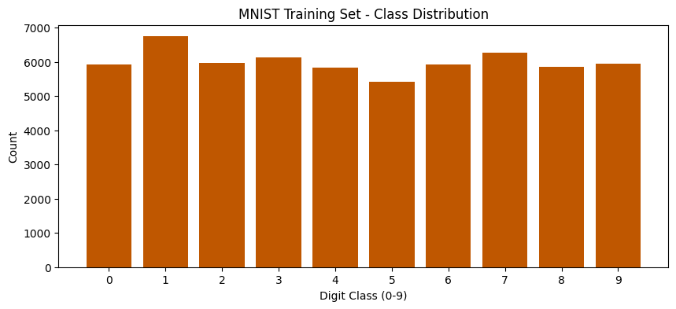

```python
# ===============================================================
# EDA - Class Distribution (Digit Counts 0–9)
# ===============================================================

# -----------------------------
# 1) Convert labels to integers (0–9) for counting
# -----------------------------
# Purpose:
# - np.bincount() requires a 1D array of integers.
# - If labels are one-hot encoded (shape: (N, 10)), convert them back to class IDs:
#     [0,0,0,1,0,0,0,0,0,0] -> 3
# - If labels are already integers (shape: (N,)), keep them as-is.
y_train_labels = np.argmax(y_train, axis=1) if y_train.ndim == 2 else y_train
y_test_labels  = np.argmax(y_test, axis=1)  if y_test.ndim == 2 else y_test

# -----------------------------
# 2) Count how many examples exist for each digit
# -----------------------------
# Purpose:
# - Check whether the dataset is balanced across classes (0–9).
# - minlength=10 guarantees we always get counts for all digits 0–9,
#   even if a class is missing in a subset (rare, but good practice).
train_counts = np.bincount(y_train_labels, minlength=10)
test_counts  = np.bincount(y_test_labels, minlength=10)

# Print raw counts for quick inspection (helps spot imbalance immediately)
print("Train label counts:", train_counts)
print("Test label counts: ", test_counts)

# -----------------------------
# 3) Visualize the class distribution
# -----------------------------
# Purpose:
# - A bar chart makes it easy to see if any digit class is under-represented.
# - Severe imbalance can bias a model toward majority classes and reduce recall on minority classes.
plt.figure(figsize=(10, 4))
plt.bar(range(10), train_counts, color="#BF5700")  # Burnt orange theme
plt.xticks(range(10))
plt.xlabel("Digit Class (0-9)")
plt.ylabel("Count")
plt.title("MNIST Training Set - Class Distribution")
plt.show()
```

#### **Insights and Analysis - Class Distribution**

#### 1) What the counts show (balance check)

- **Training set total:** 60,000 images
  - Per-class counts range from **5,421 (digit 5)** to **6,742 (digit 1)**
  - **Imbalance ratio (max/min): ~1.24×**
  - Mean per class is exactly **6,000**; variation is modest (**CV ≈ 5.37%**)
- **Test set total:** 10,000 images
  - Per-class counts range from **892 (digit 5)** to **1,135 (digit 1)**
  - **Imbalance ratio (max/min): ~1.27×**
  - Mean per class is exactly **1,000**; variation is modest (**CV ≈ 5.92%**)

#### 2) Which classes are over/under represented

Relative to the expected mean:

- **Most overrepresented:** digit **1**
  - Train: **+12.37%** vs mean (6,742 vs 6,000)
  - Test: **+13.5%** vs mean (1,135 vs 1,000)
- **Most underrepresented:** digit **5**
  - Train: **−9.65%** vs mean (5,421 vs 6,000)
  - Test: **−10.8%** vs mean (892 vs 1,000)

#### 3) Data science implications

- **Dataset is effectively "balanced enough"** for MNIST training without special handling.
- The mild skew (more **1s**, fewer **5s**) can still create small effects:
  - The model may learn slightly better decision boundaries for more frequent classes (like **1**) simply due to more examples.
  - Underrepresented classes (like **5**) may show slightly lower recall in edge cases, especially if the class is also visually ambiguous.
- Because the imbalance is modest, **no class weighting is required** for MNIST here, but it’s good practice to validate per-class metrics (which you already do via classification report + confusion matrix).

#### 4) Business impact implications

- **Risk of systematic bias is low** in this dataset, which supports stable performance across classes.
- At scale, even mild imbalance can show up operationally:
  - If a business workflow disproportionately contains certain digits (e.g., many "1"s in IDs or amounts), model behavior may appear "better" on those patterns simply due to training exposure.
  - Fewer examples of "5" can translate to more errors for that digit, which can increase downstream costs (manual review, correction loops) if "5" is common in real inputs.
- **Deployment takeaway:** this MNIST distribution is fine as a learning benchmark, but real business digit streams should be checked for their own distribution shifts (e.g., more 0s/1s/9s depending on domain).

### EDA: Visual Inspection (Random Sample Grid of Digits)

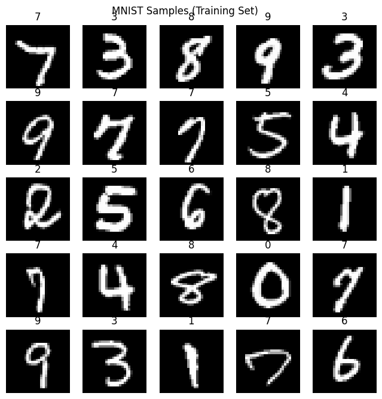

```python
# ===============================================================
# EDA - Visual Inspection (Random Sample Grid of Digits)
# ===============================================================

# -----------------------------
# 1) Convert labels to integers for display
# -----------------------------
# Purpose:
# - Titles on the images should be the actual digit (0–9).
# - If labels are one-hot encoded (shape: (N, 10)), convert back to class IDs using argmax.
# - If labels are already integers (shape: (N,)), keep them as-is.
y_train_labels = np.argmax(y_train, axis=1) if y_train.ndim == 2 else y_train

# -----------------------------
# 2) Select a reproducible random sample of images
# -----------------------------
# Purpose:
# - Visual checks confirm the data "looks right" (digits are readable, labels match images).
# - Setting a seed ensures you see the same 25 images every run (helpful for debugging and consistency).
np.random.seed(42)
idx = np.random.choice(len(x_train), 25, replace=False)  # Pick 25 unique indices from the training set

# -----------------------------
# 3) Plot a 5x5 grid of digit images with labels
# -----------------------------
# Purpose:
# - Quickly verify:
#   - image shapes are correct (28x28 with 1 channel)
#   - normalization didn't distort the images
#   - labels correspond to the image content
plt.figure(figsize=(8, 8))

for i, j in enumerate(idx):
    plt.subplot(5, 5, i + 1)                 # Create each subplot position
    plt.imshow(x_train[j].squeeze(), cmap="gray")  # squeeze() removes the extra channel dimension for display
    plt.title(int(y_train_labels[j]))        # Display the label as the subplot title (0–9)
    plt.axis("off")                          # Hide axes for a cleaner grid

# Overall title for the full grid (y controls vertical position)
plt.suptitle("MNIST Samples (Training Set)", y=0.92)
plt.show()
```

#### **Insights and Analysis - Random Sample Grid**

#### 1) What the visual sample confirms (data quality sanity check)

- The images show **high-contrast white strokes on a dark background**, which matches standard MNIST formatting.
- Digits appear **centered and consistently scaled** within the 28×28 frame (no major cropping or off-canvas strokes).
- Stroke thickness and style vary (some "thin" 1s, curved 7s, looped 9s), which is good—it means the model will learn from natural handwriting variation.

#### 2) Data science implications

- **Preprocessing is likely correct:** The digits look visually "normal," suggesting reshape and normalization did not distort the data (e.g., no inversion, no unexpected artifacts).
- **Variability supports generalization:** The visible variation across digits (curvature, slant, stroke width) helps a CNN learn more robust features, improving performance on new samples.
- **Ambiguity risk still exists:** Even in this grid, some digits can be confused depending on writing style (common MNIST confusions include **3 vs 5**, **4 vs 9**, **7 vs 1**, **8 vs 9**). This is why confusion-matrix review is valuable.
- **Sampling is not representative by itself:** This is only 25 images; it’s a qualitative check, not a statistical guarantee. It’s still an important early "sanity test."

#### 3) Business impact implications

- **Confidence in pipeline readiness:** A clean, visually correct sample increases confidence that downstream training and evaluation results are trustworthy (fewer hidden preprocessing bugs).
- **Sets expectations for real-world use:** MNIST is clean and standardized. Real business inputs (mobile photos, scans, forms) typically introduce:
  - blur and lighting variation
  - rotation/skew
  - background noise
  - inconsistent centering/cropping  
    These factors usually **reduce accuracy** unless handled with better preprocessing or augmentation.
- **Operational takeaway:** This dataset is excellent for learning and benchmarking, but production digit recognition should include:
  - input quality checks
  - confidence thresholds
  - exception handling (human review for uncertain cases)

### EDA: Pixel Intensity Distribution (Histogram)

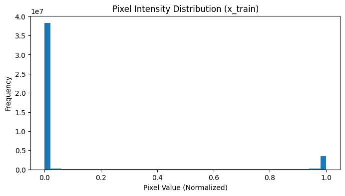

```python
# ===============================================================
# EDA - Pixel Intensity Distribution (Histogram)
# ===============================================================

# Purpose:
# - Confirm that normalization worked (pixel values should be in the range ~0.0 to ~1.0).
# - Understand how "bright" or "dark" the dataset is overall.
# - Spot anomalies (e.g., values > 1.0 or < 0.0 would indicate a preprocessing issue).

# Create a new figure so this chart is clearly separated from other plots
plt.figure(figsize=(8, 4))

# Flatten converts the entire 4D tensor (N, 28, 28, 1) into a 1D array of pixel values.
# This lets us build a single histogram across all pixels in the training set.
plt.hist(x_train.flatten(), bins=50)

# Label the chart for readability
plt.xlabel("Pixel Value (Normalized)")   # Expected range: 0.0 to 1.0
plt.ylabel("Frequency")                  # How many pixels fall into each bin
plt.title("Pixel Intensity Distribution (x_train)")

# Display the plot
plt.show()
```

#### **Insights and Analysis - Pixel Intensity Histogram**

#### 1) What the histogram is showing (data characteristics)

- The distribution is **heavily concentrated near 0.0**, with a much smaller spike near **1.0**.
- Interpretation: Most pixels in MNIST images are **background (black / near-zero intensity)**, and a smaller fraction of pixels represent the **digit strokes (bright / near-one intensity)**.
- This matches your earlier pixel stats (mean ≈ **0.13**): the dataset is dominated by dark background pixels.

#### 2) Data science implications

- **Normalization is working:** Values are clearly within the expected **0–1** range, consistent with proper scaling.
- **Sparsity is expected:** MNIST digits occupy a small portion of the 28×28 grid; most pixels carry "no stroke" information.
- **Learning signal is concentrated:** The model must learn from relatively few informative pixels (stroke regions). CNNs handle this well because they focus on local edge/shape patterns.
- **Potential metric caveat:** Because the dataset contains many near-zero pixels, some preprocessing or augmentations can appear to "work" while subtly changing stroke thickness/contrast—this histogram is a quick way to catch gross errors (e.g., inverted pixels, wrong scaling).

#### 3) Business impact implications

- **Efficiency advantage:** Sparse, high-contrast digit images are easier for models to classify accurately, enabling high automation rates in clean environments (like scanned, standardized forms).
- **Real-world risk:** Many business inputs are not this clean:
  - gray backgrounds, shadows, compression artifacts
  - faint pencil strokes or low contrast ink
  - noise, skew, blur  
    Those conditions would **shift this histogram** (more mid-range values), and usually increase misclassification risk.
- **Operational takeaway:** If you deploy digit recognition in a real workflow, monitor input distributions over time. A shift away from "mostly zeros" toward mid-range intensities can be an early warning that accuracy will degrade (and manual review cost will rise).

## Step 3: Training the Neural Network

### model.fit() - One Command, Massive Power

```python
# ===============================================================
# Train the Model (Fit)
# ===============================================================
# Goal:
# - Train the neural network so it learns to recognize digits (0–9)
# - Track performance over time so you can evaluate learning progress
# - Store results in `history` for later plotting (loss/accuracy curves)

# NOTE:
# - This section is kept for learning/reference.
# - It can re-train the CNN and overwrite cnn_history / checkpoint results.
# - It is OFF by default to keep the notebook "portfolio-safe".
RUN_SIMPLE_FIT_DEMO = False
if RUN_SIMPLE_FIT_DEMO:
    # Train the model
    history = cnn_model.fit(
        x_train, y_train,        # Training data (images + labels)

        # batch_size:
        # - Number of images processed before the model updates its weights once.
        # - 32 is a common default that balances speed and stability.
        batch_size=32,           # Process 32 images at once

        # epochs:
        # - One epoch = one full pass through the entire training dataset.
        # - 10 epochs means the model will see the training data 10 times.
        epochs=10,               # Train for 10 full passes

        # validation_split:
        # - Automatically holds out the last 20% of x_train/y_train as validation data.
        # - Validation data is NOT used to update weights; it's used to measure generalization.
        # - Useful for spotting overfitting (train accuracy rises while val accuracy stalls/drops).
        validation_split=0.2,    # 20% of data for validation

        # verbose:
        # - Controls how much training output you see.
        # - 1 shows a progress bar plus metrics per epoch (loss/accuracy and val_loss/val_accuracy).
        verbose=1                # Show progress
    )

    # After training:
    # - `history.history` contains the per-epoch metrics (loss, accuracy, val_loss, val_accuracy)
    # - You can plot these to visualize learning and detect overfitting.
```

### Summary of What This Code Does (Model Training)

This code **trains the neural network** on the MNIST training data and records learning progress in `history`.

- Calls `model.fit(x_train, y_train, ...)` to start training using the model’s current architecture and compile settings.
- Uses a **batch size of 32**, meaning the model updates its weights after processing **32 images at a time**.
- Trains for **10 epochs**, meaning the model makes **10 full passes** through the training dataset (unless training is stopped early by callbacks, if used).
- Holds out **20% of the training data** as a **validation set** (`validation_split=0.2`) to measure how well the model generalizes during training.
- Sets `verbose=1` to display a live progress bar and metrics (loss/accuracy) for each epoch.
- Stores the training results (loss/accuracy over epochs) in **`history`**, which can be used later for plotting learning curves and diagnosing overfitting.

### Expected Results - 99%+ Accuracy

- Model will correctly identify **99 out of every 100** handwritten digits
- That’s roughly **1 error per 100** predictions on the MNIST test set
- This level of performance is **near state-of-the-art for simple MNIST classifiers** and is often **comparable to (or better than) human performance** on ambiguous handwriting

### What Happens During Training

(1) Make Predicitons (Model guesses digit labels) -> (2) Calculate Error (Compare with correct answers) -> (3) Adjust weights (Slightly improve parameters) -> (4) Repeat (Millions of iterations)

### Training Result Interpretation (Data Science + Business Impact)

#### Business impact implications

# Beyond Basic Accuracy - Detailed Analysis

## Deep Dive Evaluation

```
313/313 ━━━━━━━━━━━━━━━━━━━━ 3s 10ms/step - accuracy: 0.9899 - loss: 0.0315

===============================================================
Evaluation Results: CNN Model
===============================================================
Test Loss:     0.026006
Test Accuracy: 0.992100
313/313 ━━━━━━━━━━━━━━━━━━━━ 3s 9ms/step

Classification Report:
              precision    recall  f1-score   support

           0       0.99      0.99      0.99       980
           1       0.99      1.00      1.00      1135
           2       1.00      0.99      0.99      1032
           3       0.99      0.99      0.99      1010
           4       0.99      1.00      0.99       982
           5       0.99      0.99      0.99       892
           6       0.99      0.99      0.99       958
           7       0.99      0.99      0.99      1028
           8       0.99      0.99      0.99       974
           9       0.99      0.99      0.99      1009

    accuracy                           0.99     10000
   macro avg       0.99      0.99      0.99     10000
weighted avg       0.99      0.99      0.99     10000

Confusion Matrix:
[[ 975    1    0    0    0    0    2    1    1    0]
 [   0 1132    1    1    0    0    1    0    0    0]
 [   1    0 1023    0    1    0    0    7    0    0]
 [   0    0    1 1004    0    3    0    0    2    0]
 [   0    0    0    0  978    0    1    1    0    2]
 [   0    0    1    7    0  881    1    0    1    1]
 [   2    2    0    0    2    3  948    0    1    0]
 [   0    3    1    0    1    0    0 1020    1    2]
 [   1    0    1    2    0    1    0    1  965    3]
 [   1    2    0    1    5    1    0    3    1  995]]
```

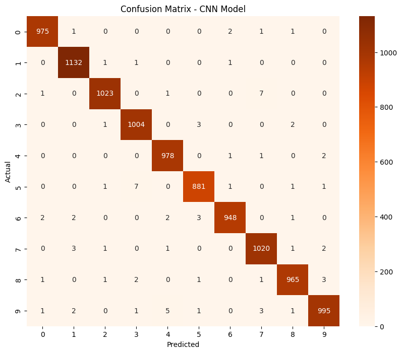

```
313/313 ━━━━━━━━━━━━━━━━━━━━ 6s 18ms/step - accuracy: 0.9745 - loss: 0.0965

===============================================================
Evaluation Results: MLP Model
===============================================================
Test Loss:     0.079807
Test Accuracy: 0.978100
313/313 ━━━━━━━━━━━━━━━━━━━━ 2s 7ms/step

Classification Report:
              precision    recall  f1-score   support

           0       0.98      0.99      0.98       980
           1       0.99      0.99      0.99      1135
           2       0.97      0.99      0.98      1032
           3       0.98      0.98      0.98      1010
           4       0.98      0.98      0.98       982
           5       0.98      0.97      0.98       892
           6       0.97      0.98      0.98       958
           7       0.98      0.97      0.98      1028
           8       0.98      0.96      0.97       974
           9       0.98      0.96      0.97      1009

    accuracy                           0.98     10000
   macro avg       0.98      0.98      0.98     10000
weighted avg       0.98      0.98      0.98     10000

Confusion Matrix:
[[ 970    0    2    1    0    1    4    0    1    1]
 [   0 1123    5    0    0    1    3    0    3    0]
 [   3    2 1018    2    1    0    2    4    0    0]
 [   1    0    4  993    0    5    0    3    2    2]
 [   0    1    0    0  960    0   11    2    2    6]
 [   2    0    0    6    2  868    5    0    5    4]
 [   4    2    1    0    3    3  941    0    4    0]
 [   2    3   16    3    1    0    0 1001    0    2]
 [   4    0    7    7    3    6    4    4  936    3]
 [   4    3    1    5   10    4    1    8    2  971]]
```

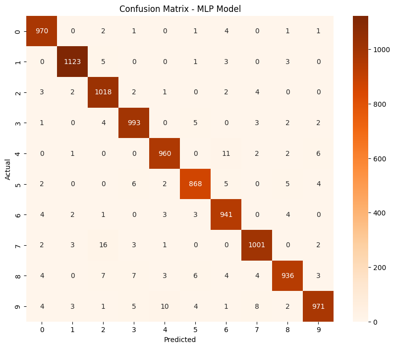

```python
# ===============================================================
# Model Evaluation + Detailed Error Analysis
# ===============================================================
# Goal:
# - Measure final model performance on the test set (unseen data)
# - Generate predictions and convert them into class labels (0–9)
# - Produce a classification report (precision/recall/F1 per digit)
# - Produce a confusion matrix (numeric + heatmap) to see where the model struggles
#
# Normal practice update:
# - Evaluate BOTH models (MLP and CNN) using the same evaluation logic.
# - CNN uses x_test as-is (shape: (N, 28, 28, 1)) and one-hot labels (N, 10)
# - MLP uses a flattened copy of x_test (shape: (N, 784)) and integer labels (N,)

# ---------------------------------------------------------------
# Evaluation helper (shared logic, used for BOTH models)
# ---------------------------------------------------------------
# Purpose:
# - Run the exact same evaluation pipeline for a given model.
# - Prints test loss/accuracy, classification report, and confusion matrix (table + heatmap).
def evaluate_model(model_to_eval, model_name, x_eval, y_eval):
    # Basic evaluation (just the start!)
    test_loss, test_accuracy = model_to_eval.evaluate(x_eval, y_eval, verbose=1)

    print("\n===============================================================")
    print(f"Evaluation Results: {model_name}")
    print("===============================================================")
    print(f"Test Loss:     {test_loss:.6f}")
    print(f"Test Accuracy: {test_accuracy:.6f}")

    # Detailed predictions analysis
    predictions = model_to_eval.predict(x_eval)

    # Convert probabilities to predicted class labels (0–9)
    predicted_classes = np.argmax(predictions, axis=1)

    # Define y_eval_original (safe for BOTH formats)
    # Purpose:
    # - If y_eval is one-hot (N,10), argmax converts to integer labels (N,)
    # - If y_eval is already integers (N,), use as-is
    y_eval_original = np.argmax(y_eval, axis=1) if getattr(y_eval, "ndim", 1) == 2 else y_eval

    # Classification report - GOLD STANDARD
    from sklearn.metrics import classification_report, confusion_matrix
    print("\nClassification Report:")
    print(classification_report(y_eval_original, predicted_classes))

    # Confusion matrix - numeric
    cm = confusion_matrix(y_eval_original, predicted_classes)
    print("Confusion Matrix:")
    print(cm)

    # Confusion matrix - graph version (seaborn heatmap)
    import seaborn as sns
    import matplotlib.pyplot as plt

    plt.figure(figsize=(10, 8))
    sns.heatmap(cm, annot=True, fmt='d', cmap='Oranges')
    plt.xlabel('Predicted')
    plt.ylabel('Actual')
    plt.title(f'Confusion Matrix - {model_name}')
    plt.show()


# ---------------------------------------------------------------
# Run evaluation for BOTH models (normal practice comparison)
# ---------------------------------------------------------------

# CNN evaluation
# Purpose:
# - CNN was compiled with categorical_crossentropy and expects one-hot labels (N,10)
evaluate_model(cnn_model, "CNN Model", x_test, y_test)

# MLP evaluation
# Purpose:
# - MLP was compiled with sparse_categorical_crossentropy and expects integer labels (N,)
# - Create a flattened copy of x_test ONLY for MLP evaluation.
# - Convert one-hot labels back to integers ONLY for MLP evaluation.
#
# IMPORTANT (surgical runtime fix):
# - Some TF/Keras notebook runtimes can raise:
#     "Creating variables on a non-first call to a function decorated with tf.function"
#   when evaluating a second model back-to-back.
# - To avoid this, we:
#   1) ensure dtype is float32 (most common TF default)
#   2) "warm up" the model once with a tiny forward pass
#   3) force eager execution ONLY for the MLP evaluation by recompiling with run_eagerly=True
x_test_mlp = x_test.reshape(-1, 784).astype(np.float32)
y_test_mlp = np.argmax(y_test, axis=1)   # one-hot (N,10) -> integers (N,)

# Warm-up forward pass (builds/initializes execution path safely)
_ = mlp_model.predict(x_test_mlp[:32], verbose=0)

# Re-compile MLP in eager mode for evaluation stability (weights stay the same)
mlp_model.compile(
    optimizer='adam',
    loss='sparse_categorical_crossentropy',
    metrics=['accuracy'],
    run_eagerly=True
)

evaluate_model(mlp_model, "MLP Model", x_test_mlp, y_test_mlp)
```

# Model Comparison - MLP vs CNN (Quantitative + Business Impact)

## Purpose

This section performs a rigorous, side-by-side comparison of two neural network approaches trained on the **MNIST handwritten digit classification** problem (digits **0–9**). The objective is to evaluate performance **quantitatively**, diagnose **error patterns**, and translate model quality differences into a **business/operational impact** framing.

## Models Compared

### 1) MLP (Multi-Layer Perceptron / Dense Network)

**Input format**

- Flattened vectors of length **784**
- Transformation: `28 × 28 → 784`

**Strengths**

- Simple architecture and easy to reason about
- Typically faster to train than CNNs
- Strong baseline for image classification when compute is limited

**Limitations**

- Loses **spatial structure** (pixel neighborhood relationships)
- Must infer shapes without explicit locality constraints, which usually hurts image performance

### 2) CNN (Convolutional Neural Network)

**Input format**

- Image tensors shaped **(28, 28, 1)**

**Strengths**

- Learns **spatial features** directly (edges, corners, curves, digit strokes)
- Convolutions preserve and exploit local pixel relationships
- Typically outperforms MLPs on image tasks due to learned feature hierarchies

## What This Comparison Includes

### A) Aggregate Performance Metrics (Test Set)

- **Accuracy** and **Error Rate**
- **Precision / Recall / F1** using:
  - **Macro averaging** (each class treated equally; useful for fairness across digits)
  - **Weighted averaging** (weighted by class frequency; useful overall summary)

### B) Error Diagnostics

- **Confusion matrix** for each model:
  - numeric matrix
  - heatmap visualization (consistent styling across models)
- **Per-class recall for digits 0–9**
  - Reveals where each model struggles (e.g., confusing 4 vs 9, 3 vs 5, etc.)

## Business Impact Translation (Why This Matters Beyond "Accuracy")

In real workflows, classification errors have practical cost, such as:

- manual review effort
- downstream automation failures
- customer-facing issues and rework
- exception handling and operational overhead

This section includes a **simple estimator** that converts:

- the **difference in error rates** into:
- the **expected difference in misclassifications per day**, given a daily prediction volume and optionally:
- an **estimated manual review cost impact** using clearly stated placeholder assumptions

> Important: MNIST is used here as a learning dataset. The business framing is included to demonstrate a professional ability to translate model metrics into operational terms in real systems.

## Fairness Note

This comparison intentionally uses the **same MNIST test set** for both models to ensure an apples-to-apples evaluation. The only differences are:

- the **model architecture** (MLP vs CNN)
- the required **input shape**
- the required **label encoding / loss pairing** for each workflow

```python
# ===============================================================
# Model Comparison - Quantitative Evaluation (MLP vs CNN) [NO-DUP OUTPUT MODE]
# ===============================================================
# Goal:
# - Compute comparable metrics for both models on the same MNIST test set.
# - Present results in a clean, portfolio-quality summary.
# - Translate metric deltas into operational/business impact (volume-based).
#
# Output Policy (Portfolio):
# - The "Model Evaluation + Detailed Error Analysis" section already prints:
#   - classification report + confusion matrix + heatmap
# - Therefore, this comparison section intentionally avoids duplicating:
#   - confusion matrix numeric output
#   - confusion matrix heatmaps
#   - full per-class tables that replicate the classification report
#
# Instead, this section adds VALUE by showing:
# - a concise side-by-side metrics table
# - business impact translation
# - top confusion pairs (actionable error patterns) per model
# ===============================================================

import numpy as np
import pandas as pd

from sklearn.metrics import (
    accuracy_score,
    precision_score,
    recall_score,
    f1_score,
    confusion_matrix
)

# -----------------------------
# 0) Business/Operational Impact Assumption (Volume-Based)
# -----------------------------
# Purpose:
# - Translate error rates into an intuitive "expected misclassifications" number.
# - If you have a preferred volume already defined earlier (daily_volume), this cell will use it.
# - If not, we define a safe, portfolio-friendly default so the cell never fails.
try:
    daily_volume
except NameError:
    daily_volume = 10_000  # default assumption for operational translation (edit if desired)

# Guard-rail: ensure it's numeric
if not isinstance(daily_volume, (int, float)) or daily_volume <= 0:
    raise ValueError(f"daily_volume must be a positive number. Got: {daily_volume}")

# -----------------------------
# 1) Prepare "ground truth" labels in integer form for fair comparison
# -----------------------------
# Guard-rail:
# - If y_test is one-hot (N,10), convert to integer labels (N,)
# - If y_test is already integer (N,), keep it as-is
if len(y_test.shape) == 2 and y_test.shape[1] == 10:
    y_test_int = np.argmax(y_test, axis=1)
else:
    y_test_int = y_test.astype(int)

# -----------------------------
# 2) Ensure MLP-specific test pipeline exists (without mutating CNN pipeline)
# -----------------------------
try:
    _ = x_test_mlp
except NameError:
    if len(x_test.shape) == 4 and x_test.shape[1:] == (28, 28, 1):
        x_test_mlp = x_test.reshape(-1, 784).astype(np.float32)
    elif len(x_test.shape) == 3 and x_test.shape[1:] == (28, 28):
        x_test_mlp = x_test.reshape(-1, 784).astype(np.float32)
    else:
        x_test_mlp = x_test.astype(np.float32)

try:
    _ = y_test_mlp
except NameError:
    y_test_mlp = y_test_int

# -----------------------------
# 3) Get predictions for both models (MLP first, then CNN)
# -----------------------------
mlp_probs = mlp_model.predict(x_test_mlp, verbose=0)
mlp_pred = np.argmax(mlp_probs, axis=1)

cnn_probs = cnn_model.predict(x_test, verbose=0)
cnn_pred = np.argmax(cnn_probs, axis=1)

# -----------------------------
# 4) Compute metrics (macro + weighted)
# -----------------------------
def compute_metrics(y_true, y_pred):
    acc = accuracy_score(y_true, y_pred)
    err = 1.0 - acc

    metrics = {
        "Accuracy": acc,
        "Error Rate": err,

        # Macro: treats each class equally (fairness across digits)
        "Precision (Macro)": precision_score(y_true, y_pred, average="macro", zero_division=0),
        "Recall (Macro)":    recall_score(y_true, y_pred, average="macro", zero_division=0),
        "F1 (Macro)":        f1_score(y_true, y_pred, average="macro", zero_division=0),

        # Weighted: accounts for class frequency (overall summary)
        "Precision (Weighted)": precision_score(y_true, y_pred, average="weighted", zero_division=0),
        "Recall (Weighted)":    recall_score(y_true, y_pred, average="weighted", zero_division=0),
        "F1 (Weighted)":        f1_score(y_true, y_pred, average="weighted", zero_division=0),
    }
    return metrics

mlp_metrics = compute_metrics(y_test_int, mlp_pred)
cnn_metrics = compute_metrics(y_test_int, cnn_pred)

comparison_df = pd.DataFrame([mlp_metrics, cnn_metrics], index=["MLP", "CNN"])

print("\n===============================================================")
print("Quantitative Model Comparison (Test Set) - Executive Summary")
print("===============================================================")
display(comparison_df)

# -----------------------------
# 5) Top confusion pairs (adds insight WITHOUT reprinting heatmaps)
# -----------------------------
# Why this is valuable:
# - Your other evaluation cell already shows the full confusion matrix + heatmap.
# - For portfolio readability, we surface only the top "where it goes wrong" pairs here.
digits = list(range(10))

def top_confusions(y_true, y_pred, labels, top_n=10):
    cm = confusion_matrix(y_true, y_pred, labels=labels)
    # Zero-out diagonal (correct predictions) to focus on mistakes
    cm_off = cm.copy()
    np.fill_diagonal(cm_off, 0)

    pairs = []
    for actual_idx, actual_label in enumerate(labels):
        for pred_idx, pred_label in enumerate(labels):
            count = cm_off[actual_idx, pred_idx]
            if count > 0:
                pairs.append((actual_label, pred_label, int(count)))

    pairs_sorted = sorted(pairs, key=lambda x: x[2], reverse=True)[:top_n]
    return pd.DataFrame(pairs_sorted, columns=["Actual", "Predicted", "Count"])

mlp_top = top_confusions(y_test_int, mlp_pred, digits, top_n=10)
cnn_top = top_confusions(y_test_int, cnn_pred, digits, top_n=10)

print("\n===============================================================")
print("Top Confusion Pairs (MLP) - Most Frequent Misclassifications")
print("===============================================================")
display(mlp_top)

print("\n===============================================================")
print("Top Confusion Pairs (CNN) - Most Frequent Misclassifications")
print("===============================================================")
display(cnn_top)

# -----------------------------
# 6) Business Impact Translation (Volume-Based)
# -----------------------------
mlp_error = float(comparison_df.loc["MLP", "Error Rate"])
cnn_error = float(comparison_df.loc["CNN", "Error Rate"])

mlp_misclass = daily_volume * mlp_error
cnn_misclass = daily_volume * cnn_error

delta_misclass = mlp_misclass - cnn_misclass  # positive means CNN reduces errors

print("\n===============================================================")
print("Operational Impact (Volume-Based Translation)")
print("===============================================================")
print(f"Assumed daily volume:                         {daily_volume:,.0f} items/day")
print(f"MLP expected misclassifications/day:          {mlp_misclass:,.2f}")
print(f"CNN expected misclassifications/day:          {cnn_misclass:,.2f}")
print(f"Expected reduction with CNN vs MLP per day:   {delta_misclass:,.2f}")
```

```
===============================================================
Quantitative Model Comparison (Test Set) - Executive Summary
===============================================================
```

|  | Accuracy | Error Rate | Precision (Macro) | Recall (Macro) | F1 (Macro) | Precision (Weighted) | Recall (Weighted) | F1 (Weighted) |
| --- | --- | --- | --- | --- | --- | --- | --- | --- |
| MLP | 0.9781 | 0.0219 | 0.977987 | 0.977883 | 0.977896 | 0.978151 | 0.9781 | 0.978086 |
| CNN | 0.9921 | 0.0079 | 0.992105 | 0.991985 | 0.992041 | 0.992106 | 0.9921 | 0.992098 |

```
===============================================================
Top Confusion Pairs (MLP) - Most Frequent Misclassifications
===============================================================
```

|  | Actual | Predicted | Count |
| --- | --- | --- | --- |
| 0 | 7 | 2 | 16 |
| 1 | 4 | 6 | 11 |
| 2 | 9 | 4 | 10 |
| 3 | 9 | 7 | 8 |
| 4 | 8 | 2 | 7 |
| 5 | 8 | 3 | 7 |
| 6 | 4 | 9 | 6 |
| 7 | 5 | 3 | 6 |
| 8 | 8 | 5 | 6 |
| 9 | 1 | 2 | 5 |

```
===============================================================
Top Confusion Pairs (CNN) - Most Frequent Misclassifications
===============================================================
```

|  | Actual | Predicted | Count |
| --- | --- | --- | --- |
| 0 | 2 | 7 | 7 |
| 1 | 5 | 3 | 7 |
| 2 | 9 | 4 | 5 |
| 3 | 3 | 5 | 3 |
| 4 | 6 | 5 | 3 |
| 5 | 7 | 1 | 3 |
| 6 | 8 | 9 | 3 |
| 7 | 9 | 7 | 3 |
| 8 | 0 | 6 | 2 |
| 9 | 3 | 8 | 2 |

```
===============================================================
Operational Impact (Volume-Based Translation)
===============================================================
Assumed daily volume:                         10,000 items/day
MLP expected misclassifications/day:          219.00
CNN expected misclassifications/day:          79.00
Expected reduction with CNN vs MLP per day:   140.00
```

# Misclassification Analysis - Example-Level Error Inspection

Purpose: Aggregate metrics (accuracy, confusion matrix, classification report) show overall performance, but they do not show what the model actually gets wrong.

This section adds example-level error inspection for BOTH models:

- MLP (flattened pipeline)
- CNN (image tensor pipeline)

Outputs:

1. Ranked table of misclassified examples with:
   - True label
   - Predicted label
   - Prediction confidence (max softmax probability)
2. Grid of misclassified images (human-verifiable errors)

Guard-Rails:

- Additive-only and does NOT modify x_test / y_test.
- Derives integer ground-truth labels safely (argmax if one-hot).
- Uses x_test for plotting so mistakes are visually interpretable.

```
===============================================================
Misclassification Summary (Top 20 Most-Confident Mistakes) — MLP
===============================================================
```

|  | Index | True | Pred | Confidence_% |
| --- | --- | --- | --- | --- |
| 0 | 1112 | 4 | 6 | 100.000000 |
| 1 | 445 | 6 | 0 | 99.989998 |
| 2 | 9009 | 7 | 2 | 99.989998 |
| 3 | 2654 | 6 | 1 | 99.989998 |
| 4 | 4176 | 2 | 7 | 99.989998 |
| 5 | 1226 | 7 | 2 | 99.970001 |
| 6 | 720 | 5 | 8 | 99.970001 |
| 7 | 1549 | 4 | 6 | 99.970001 |
| 8 | 6574 | 2 | 6 | 99.970001 |
| 9 | 4880 | 0 | 8 | 99.959999 |
| 10 | 9015 | 7 | 2 | 99.959999 |
| 11 | 9024 | 7 | 2 | 99.949997 |
| 12 | 9587 | 9 | 4 | 99.930000 |
| 13 | 9729 | 5 | 6 | 99.910004 |
| 14 | 3503 | 9 | 1 | 99.879997 |
| 15 | 3776 | 5 | 8 | 99.879997 |
| 16 | 8325 | 0 | 6 | 99.830002 |
| 17 | 2053 | 4 | 9 | 99.800003 |
| 18 | 5887 | 7 | 0 | 99.750000 |
| 19 | 2043 | 4 | 8 | 99.709999 |

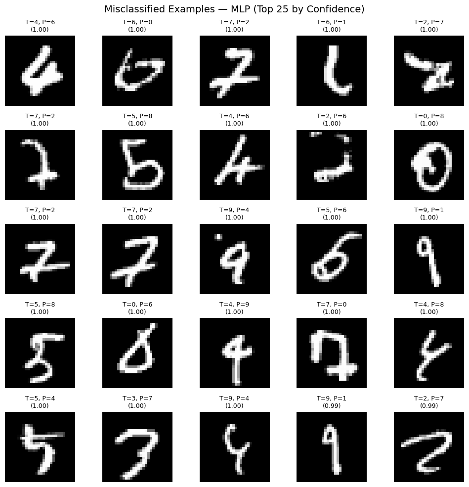

```
===============================================================
Misclassification Summary (Top 20 Most-Confident Mistakes) — CNN
===============================================================
```

|  | Index | True | Pred | Confidence_% |
| --- | --- | --- | --- | --- |
| 0 | 9729 | 5 | 6 | 100.000000 |
| 1 | 2654 | 6 | 1 | 99.980003 |
| 2 | 1014 | 6 | 5 | 99.980003 |
| 3 | 4176 | 2 | 7 | 99.949997 |
| 4 | 2896 | 8 | 0 | 99.870003 |
| 5 | 2597 | 5 | 3 | 99.639999 |
| 6 | 5937 | 5 | 3 | 99.610001 |
| 7 | 947 | 8 | 9 | 99.500000 |
| 8 | 4740 | 3 | 5 | 99.489998 |
| 9 | 2035 | 5 | 3 | 99.370003 |
| 10 | 3727 | 8 | 9 | 99.230003 |
| 11 | 2130 | 4 | 9 | 99.169998 |
| 12 | 1901 | 9 | 4 | 99.099998 |
| 13 | 3941 | 4 | 6 | 99.019997 |
| 14 | 2135 | 6 | 1 | 98.839996 |
| 15 | 3520 | 6 | 4 | 98.660004 |
| 16 | 8325 | 0 | 6 | 98.320000 |
| 17 | 2939 | 9 | 5 | 98.260002 |
| 18 | 321 | 2 | 7 | 97.860001 |
| 19 | 1530 | 8 | 7 | 96.919998 |

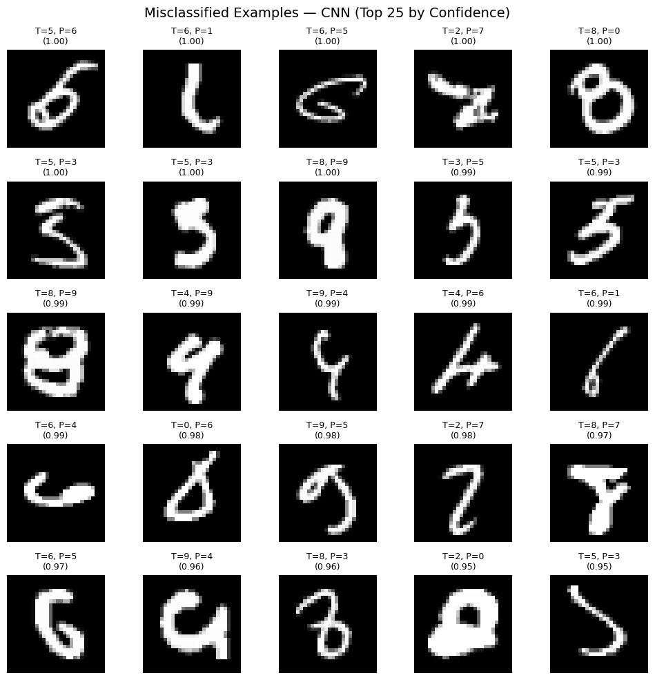

```python
# ===============================================================
# Misclassification Analysis — Example-Level Error Inspection (MLP + CNN)
# ===============================================================
# Goal:
# - Identify misclassified test samples for BOTH models.
# - Show true label vs predicted label + confidence for mistakes.
# - Display a misclassified image grid for human verification.
#
# Portfolio Constraints:
# - Additive-only: do not modify earlier evaluation cells.
# - Do not mutate x_test / y_test.
# - Minimize duplicate console output (tables + grids only).
# ===============================================================

import numpy as np
import pandas as pd
import matplotlib.pyplot as plt

# -----------------------------
# 1) Ground truth labels in integer form (safe for one-hot or integer)
# -----------------------------
if getattr(y_test, "ndim", 1) == 2 and y_test.shape[1] == 10:
    y_test_int = np.argmax(y_test, axis=1)
else:
    y_test_int = y_test.astype(int)

# -----------------------------
# 2) Ensure MLP test inputs exist (without mutating CNN pipeline)
# -----------------------------
try:
    _ = x_test_mlp
except NameError:
    if getattr(x_test, "ndim", 1) == 4 and x_test.shape[1:] == (28, 28, 1):
        x_test_mlp = x_test.reshape(-1, 784).astype(np.float32)
    elif getattr(x_test, "ndim", 1) == 3 and x_test.shape[1:] == (28, 28):
        x_test_mlp = x_test.reshape(-1, 784).astype(np.float32)
    else:
        x_test_mlp = x_test.astype(np.float32)

try:
    _ = y_test_mlp
except NameError:
    y_test_mlp = y_test_int

# -----------------------------
# 3) Helper: misclassification table + indices
# -----------------------------
def build_misclassification_artifacts(model_obj, model_name, x_eval, y_true_int, top_n=20):
    probs = model_obj.predict(x_eval, verbose=0)
    pred = np.argmax(probs, axis=1)
    conf = np.max(probs, axis=1)

    wrong_mask = pred != y_true_int
    wrong_idx = np.where(wrong_mask)[0]

    # Most confident mistakes first
    wrong_idx_sorted = wrong_idx[np.argsort(conf[wrong_idx])[::-1]]

    pick = wrong_idx_sorted[:top_n]

    mistakes_df = pd.DataFrame({
        "Index": pick,
        "True": y_true_int[pick],
        "Pred": pred[pick],
        "Confidence_%": (conf[pick] * 100.0).round(2),
    })

    print("\n===============================================================")
    print(f"Misclassification Summary (Top {min(top_n, len(wrong_idx_sorted))} Most-Confident Mistakes) — {model_name}")
    print("===============================================================")

    try:
        display(mistakes_df)
    except NameError:
        print(mistakes_df.to_string(index=False))

    return mistakes_df, wrong_idx_sorted, probs, pred, conf

# -----------------------------
# 4) Helper: plot misclassified image grid
# -----------------------------
def plot_misclassified_grid(model_name, x_images_for_plot, y_true_int, pred_int, conf, wrong_idx_sorted, grid_n=25):
    if wrong_idx_sorted.size == 0:
        print(f"\nNo misclassifications found for {model_name}.")
        return

    n = min(grid_n, wrong_idx_sorted.size)
    pick = wrong_idx_sorted[:n]

    imgs = x_images_for_plot[pick]
    if getattr(imgs, "ndim", 1) == 4 and imgs.shape[-1] == 1:
        imgs = imgs[..., 0]

    grid_size = int(np.ceil(np.sqrt(n)))

    plt.figure(figsize=(10, 10))
    for i, idx in enumerate(pick):
        plt.subplot(grid_size, grid_size, i + 1)
        plt.imshow(imgs[i], cmap="gray")
        plt.axis("off")
        plt.title(f"T={y_true_int[idx]}, P={pred_int[idx]}\n({conf[idx]:.2f})", fontsize=9)

    plt.suptitle(f"Misclassified Examples — {model_name} (Top {n} by Confidence)", fontsize=14)
    plt.tight_layout()
    plt.show()

# ===============================================================
# 5) RUN: MLP FIRST (matches your notebook flow)
# ===============================================================
mlp_mistakes_df, mlp_wrong_idx_sorted, mlp_probs, mlp_pred, mlp_conf = build_misclassification_artifacts(
    model_obj=mlp_model,
    model_name="MLP",
    x_eval=x_test_mlp,
    y_true_int=y_test_int,
    top_n=20
)

plot_misclassified_grid(
    model_name="MLP",
    x_images_for_plot=x_test,   # plot real images for interpretability
    y_true_int=y_test_int,
    pred_int=mlp_pred,
    conf=mlp_conf,
    wrong_idx_sorted=mlp_wrong_idx_sorted,
    grid_n=25
)

# ===============================================================
# 6) RUN: CNN
# ===============================================================
cnn_mistakes_df, cnn_wrong_idx_sorted, cnn_probs, cnn_pred, cnn_conf = build_misclassification_artifacts(
    model_obj=cnn_model,
    model_name="CNN",
    x_eval=x_test,
    y_true_int=y_test_int,
    top_n=20
)

plot_misclassified_grid(
    model_name="CNN",
    x_images_for_plot=x_test,
    y_true_int=y_test_int,
    pred_int=cnn_pred,
    conf=cnn_conf,
    wrong_idx_sorted=cnn_wrong_idx_sorted,
    grid_n=25
)
```

## Precision

- Of all predicited8x, how many were actually 8s?
- True Positives / (True + False Positives)

## Recall

- Of all actual 8s, how many did we catch?
- True Positives / (True Positives + False Negatives)

## F1-Score

- Balanced measure of precision and recall
- 2 x (Precision x Recall) / (Precision + Recall)

## Model Performance Summary (MNIST Digit Classification)

### Per-class error counts (from the confusion matrix)

This aligns with the classification report where **5/6/8/9** tend to have slightly lower recall than the easiest digits.

## Confusion Matrix Insights (what the model confuses most)

Interpretation (data science):

- These confusions are consistent with **shape similarity** in handwritten digits:
  - **5 vs 3** can look similar when the top curve closes.
  - **6 vs 0/5** when the loop is ambiguous or the tail is faint.
  - **8 vs 9** when the lower loop is weak or incomplete.
  - **2 vs 7** when the 2 is angular or the 7 has a stroke.

## What this means in practice (business impact)

### Why 99% can still matter a lot

Whether that’s acceptable depends on the cost of a mistake:

- **Low-stakes** (sorting, indexing, search): 99% is often excellent.
- **High-stakes** (financial amounts, account numbers, compliance forms): a 1% digit error rate can be expensive—mis-posted transactions, incorrect IDs, rework, customer friction, audit issues.

### Where your model is most "business-risky"

Digits with higher error counts (**9, 8, 6, 5**) represent **higher operational risk**, especially in contexts where those digits are common or critical (e.g., invoice totals, ID fields).

## Practical next steps (optional suggestions)

1. **Confidence-based routing (human-in-the-loop)**
   - Only auto-accept predictions above a confidence threshold (e.g., 0.95–0.99).
   - Route low-confidence cases (often the ambiguous **5/6/8/9**-like shapes) for review.
2. **Error-aware post-processing**
   - If the digit is part of a structured field, apply simple validation rules:
     - checksums, expected ranges, formatting constraints, etc.
   - This can catch and correct common confusions like **5↔3** or **8↔9**.
3. **Real-world robustness**
   - MNIST is clean and centered. Real images (photos/scans) introduce blur, skew, lighting, background noise.
   - If your goal is "business OCR," consider augmentations or a dataset closer to your real input conditions.

# Visualization - Your Diagnostic Tools

## Training History Plots

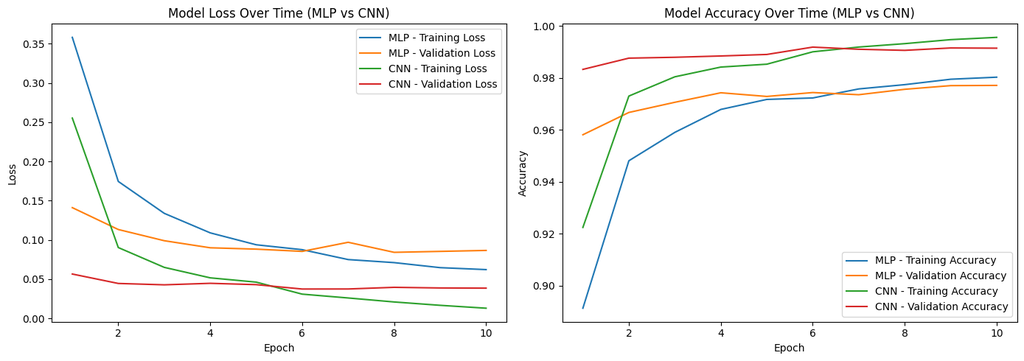

```python
# ===============================================================
# Plot Training Curves - CRUCIAL for Debugging (MLP vs CNN)
# ===============================================================
# Goal:
# - Visualize how each model learned over time (epoch by epoch)
# - Detect common training issues such as:
#   - Overfitting: training improves while validation gets worse
#   - Underfitting: both training and validation stay poor
#   - Instability: metrics bounce wildly (often learning rate / batch size issues)
#
# IMPORTANT (Portfolio Guard-Rail):
# - This notebook uses model-specific history variables:
#   - MLP training history:  mlp_history
#   - CNN training history:  cnn_history
# - We intentionally DO NOT use a generic variable name like `history`
#   because it can accidentally point to a different run/cell.
#
# NOTE:
# - Each history object comes from: model.fit(...)
# - history.history is a dict with per-epoch metric arrays
# ===============================================================

# Guard-rail: ensure matplotlib is available in this cell
import matplotlib.pyplot as plt

# -----------------------------
# 1) Verify required history objects exist
# -----------------------------
missing = []
if 'mlp_history' not in globals() or mlp_history is None:
    missing.append("mlp_history")
if 'cnn_history' not in globals() or cnn_history is None:
    missing.append("cnn_history")

if missing:
    raise NameError(
        "Missing required training history object(s): "
        + ", ".join(missing)
        + ".\nRun the corresponding MLP/CNN training cell(s) first so mlp_history and cnn_history exist."
    )

# -----------------------------
# 2) Helper to safely fetch metrics from history
# -----------------------------
def safe_get_metric(hist_obj, key_primary, key_fallback=None):
    """
    Return a metric list from a Keras History object.
    - key_primary: expected key (e.g., 'accuracy')
    - key_fallback: alternative key if primary is missing (e.g., 'acc')
    """
    if key_primary in hist_obj.history:
        return hist_obj.history[key_primary]
    if key_fallback and key_fallback in hist_obj.history:
        return hist_obj.history[key_fallback]
    raise KeyError(
        f"Metric '{key_primary}' not found in history. Available keys: {list(hist_obj.history.keys())}"
    )

# -----------------------------
# 3) Extract metrics (MLP + CNN)
# -----------------------------
# Loss
mlp_loss     = safe_get_metric(mlp_history, 'loss')
mlp_val_loss = safe_get_metric(mlp_history, 'val_loss')

cnn_loss     = safe_get_metric(cnn_history, 'loss')
cnn_val_loss = safe_get_metric(cnn_history, 'val_loss')

# Accuracy (handle possible legacy 'acc' naming)
mlp_acc     = safe_get_metric(mlp_history, 'accuracy', key_fallback='acc')
mlp_val_acc = safe_get_metric(mlp_history, 'val_accuracy', key_fallback='val_acc')

cnn_acc     = safe_get_metric(cnn_history, 'accuracy', key_fallback='acc')
cnn_val_acc = safe_get_metric(cnn_history, 'val_accuracy', key_fallback='val_acc')

# Epoch indices (Keras histories can have different epoch lengths if EarlyStopping ended early)
mlp_epochs = list(range(1, len(mlp_loss) + 1))
cnn_epochs = list(range(1, len(cnn_loss) + 1))

# -----------------------------
# 4) Plot - Side-by-side (Loss / Accuracy), with both models overlaid
# -----------------------------
plt.figure(figsize=(14, 5))

# -----------------------------
# Loss curves
# -----------------------------
plt.subplot(1, 2, 1)
plt.plot(mlp_epochs, mlp_loss, label='MLP - Training Loss')
plt.plot(mlp_epochs, mlp_val_loss, label='MLP - Validation Loss')
plt.plot(cnn_epochs, cnn_loss, label='CNN - Training Loss')
plt.plot(cnn_epochs, cnn_val_loss, label='CNN - Validation Loss')
plt.title('Model Loss Over Time (MLP vs CNN)')
plt.xlabel('Epoch')
plt.ylabel('Loss')
plt.legend()

# -----------------------------
# Accuracy curves
# -----------------------------
plt.subplot(1, 2, 2)
plt.plot(mlp_epochs, mlp_acc, label='MLP - Training Accuracy')
plt.plot(mlp_epochs, mlp_val_acc, label='MLP - Validation Accuracy')
plt.plot(cnn_epochs, cnn_acc, label='CNN - Training Accuracy')
plt.plot(cnn_epochs, cnn_val_acc, label='CNN - Validation Accuracy')
plt.title('Model Accuracy Over Time (MLP vs CNN)')
plt.xlabel('Epoch')
plt.ylabel('Accuracy')
plt.legend()

plt.tight_layout()
plt.show()
```

## Overfitting Detection Guide

- Training accuracy keep improving
- Validation accuracy plateaues/decreases
- Large gap between train/validation loss

## Healthy Training

- Both accuracies improve together
- Small gap between train/validation
- Smooth, consistent improvement

## Insight and Analysis - Training History

### **Training Curves Analysis (Loss Chart + Accuracy Chart)**

# Advanced Callbacks - Your AI Assistants

## Automated Training Optimization

```python
# ===============================================================
# OPTIONAL: Advanced Callback Demo (Disabled by Default)
# ===============================================================
# NOTE:
# - This section is kept for learning/reference.
# - It can re-train the CNN and overwrite history, so it is OFF by default.
# - To run it intentionally, set RUN_ADVANCED_CALLBACK_DEMO = True.

RUN_ADVANCED_CALLBACK_DEMO = False
if RUN_ADVANCED_CALLBACK_DEMO:
    # ===============================================================
    # Training Callbacks (Learning Rate Scheduling, Checkpoints, Early Stopping)
    # ===============================================================
    # Goal:
    # - Improve training stability and final performance without manually tuning every run
    # - Automatically reduce learning rate when progress stalls
    # - Automatically save the best model weights to disk
    # - Automatically stop training if validation performance stops improving

    from tensorflow.keras.callbacks import ReduceLROnPlateau, ModelCheckpoint, EarlyStopping

    # -----------------------------
    # 1) Smart learning rate reduction
    # -----------------------------
    # ReduceLROnPlateau:
    # - Watches a metric (here: val_loss)
    # - If that metric stops improving for `patience` epochs, it reduces the learning rate
    # - This often helps the model "fine tune" after it plateaus
    lr_scheduler = ReduceLROnPlateau(
        monitor='val_loss',   # Watch validation loss (lower is better)
        factor=0.5,           # When plateaued, multiply the learning rate by 0.5 (cut in half)
        patience=3,           # Wait 3 epochs with no improvement before reducing LR
        min_lr=1e-7           # Floor: never reduce LR below this value (prevents LR from becoming uselessly tiny)
    )

    # -----------------------------
    # 2) Auto-save best model
    # -----------------------------
    # ModelCheckpoint:
    # - Saves the model to disk whenever the monitored metric improves
    # - This guarantees you keep the best-performing model seen during training
    checkpoint = ModelCheckpoint(
        'best_model.keras',       # Save location (Keras recommended format)
        save_best_only=True,      # Only save when performance improves (prevents overwriting with worse models)
        monitor='val_accuracy',   # Watch validation accuracy (higher is better)
        mode='max'                # "max" means higher metric values are better
    )

    # -----------------------------
    # 3) Stop early if no improvement
    # -----------------------------
    # EarlyStopping:
    # - Stops training when the monitored metric stops improving
    # - Prevents wasting time/compute and reduces overfitting risk
    # - restore_best_weights=True returns the model to the best observed weights
    early_stop = EarlyStopping(
        monitor='val_loss',       # Watch validation loss (lower is better)
        patience=7,               # Wait 7 epochs for improvement before stopping
        restore_best_weights=True # After stopping, automatically roll back to the best weights
    )

    # -----------------------------
    # 4) Use all callbacks in training
    # -----------------------------
    # IMPORTANT PATCH (why you got NameError):
    # - You renamed your models to `mlp_model` and `cnn_model`.
    # - That means `model` no longer exists in your notebook at this point.
    # - Normal practice is to train the specific model you intend to train here.
    #
    # Action:
    # - Replace `model.fit(...)` with the model you actually want to train here.
    # - Below, I default this callback training block to the CNN (since your x_train is 28x28x1 and y_train is one-hot).

    history = cnn_model.fit(
        x_train, y_train,                 # Training data (images + one-hot labels)
        validation_split=0.2,             # Hold out 20% of training data for validation
        epochs=100,                       # Max epochs; early stopping will likely stop earlier
        callbacks=[lr_scheduler, checkpoint, early_stop]  # Apply all training callbacks
    )
```

# Best Checkpoint Evaluation - Best Model vs Final Epoch Model

Purpose: During training, the "final epoch" model is not always the best-performing model on validation data. Professional workflows commonly save the "best" model checkpoint (based on validation performance) and evaluate it separately on the test set to demonstrate generalization.

What this section does:

1. Confirms the checkpoint file exists (guard-rail).
2. Loads the best checkpoint model from disk.
3. Evaluates:
   - Final trained model performance (end of training)
   - Best checkpoint performance (best validation snapshot)
4. Presents results in a side-by-side comparison table + interpretation.

Guard-Rails:

- Additive-only: does not modify existing models or training cells.
- Uses explicit model names (cnn_final_model, cnn_best_model) to avoid ambiguity.

```python
# ===============================================================
# Best Checkpoint Evaluation — Load + Compare (CNN)
# ===============================================================
# NOTE:
# - Update CHECKPOINT_PATH to match the exact filename used in ModelCheckpoint earlier.
# - This cell is additive-only and does not modify your existing cnn_model object.
# ===============================================================

import os
import pandas as pd
import tensorflow as tf

# -----------------------------
# 1) Configure checkpoint path (MUST match your ModelCheckpoint)
# -----------------------------
CHECKPOINT_PATH = "best_model.keras"   # <-- UPDATE THIS to the exact filename you found via Ctrl+F

print("\n===============================================================")
print("Best Checkpoint Evaluation — Guard-Rail File Check")
print("===============================================================")
print(f"Checkpoint expected at: {CHECKPOINT_PATH}")

if not os.path.exists(CHECKPOINT_PATH):
    raise FileNotFoundError(
        f"Checkpoint file not found: {CHECKPOINT_PATH}\n"
        f"Fix: Ctrl+F for 'ModelCheckpoint' and copy the exact filepath used there.\n"
        f"Then update CHECKPOINT_PATH to match it exactly."
    )

print("Checkpoint file found ✅")

# -----------------------------
# 2) Load best checkpoint model
# -----------------------------
print("\n===============================================================")
print("Loading Best Checkpoint Model")
print("===============================================================")

cnn_best_model = tf.keras.models.load_model(CHECKPOINT_PATH)
print("Best checkpoint loaded ✅")

# -----------------------------
# 3) Evaluate final model vs best checkpoint
# -----------------------------
# Guard-rail: CNN uses x_test (image tensors) and y_test (likely one-hot)
print("\n===============================================================")
print("Evaluating Final CNN Model (End of Training)")
print("===============================================================")

final_loss, final_acc = cnn_model.evaluate(x_test, y_test, verbose=0)

print("\n===============================================================")
print("Evaluating Best Checkpoint CNN Model (Best Validation Snapshot)")
print("===============================================================")

best_loss, best_acc = cnn_best_model.evaluate(x_test, y_test, verbose=0)

# -----------------------------
# 4) Compare results in a clean portfolio table
# -----------------------------
comparison = pd.DataFrame(
    {
        "Test Loss": [final_loss, best_loss],
        "Test Accuracy": [final_acc, best_acc],
    },
    index=["Final Epoch Model", "Best Checkpoint Model"]
)

comparison["Accuracy Delta (Best - Final)"] = comparison["Test Accuracy"] - final_acc
comparison["Loss Delta (Best - Final)"] = comparison["Test Loss"] - final_loss

print("\n===============================================================")
print("Best Checkpoint vs Final Model — Test Set Comparison")
print("===============================================================")

try:
    display(comparison)
except NameError:
    print(comparison.to_string())

# -----------------------------
# 5) Interpretation helper (tight + portfolio-friendly)
# -----------------------------
acc_delta = float(best_acc - final_acc)
loss_delta = float(best_loss - final_loss)

print("\n===============================================================")
print("Interpretation (Portfolio-Grade)")
print("===============================================================")

if acc_delta > 0:
    print(f"- Best checkpoint improves test accuracy by {acc_delta:.6f} vs the final epoch model.")
elif acc_delta < 0:
    print(f"- Best checkpoint is lower by {abs(acc_delta):.6f} test accuracy vs the final epoch model.")
else:
    print("- Best checkpoint and final model have identical test accuracy (to the displayed precision).")

print("- Why this matters: saving and evaluating the best validation checkpoint is standard practice to reduce overfitting risk and demonstrate generalization.")
```

```
===============================================================
Best Checkpoint Evaluation — Guard-Rail File Check
===============================================================
Checkpoint expected at: best_model.keras
Checkpoint file found ✅

===============================================================
Loading Best Checkpoint Model
===============================================================
Best checkpoint loaded ✅

===============================================================
Evaluating Final CNN Model (End of Training)
===============================================================

===============================================================
Evaluating Best Checkpoint CNN Model (Best Validation Snapshot)
===============================================================

===============================================================
Best Checkpoint vs Final Model — Test Set Comparison
===============================================================
```

|  | Test Loss | Test Accuracy | Accuracy Delta (Best - Final) | Loss Delta (Best - Final) |
| --- | --- | --- | --- | --- |
| Final Epoch Model | 0.026006 | 0.9921 | 0.0000 | 0.000000 |
| Best Checkpoint Model | 0.025368 | 0.9922 | 0.0001 | -0.000638 |

```
===============================================================
Interpretation (Portfolio-Grade)
===============================================================
- Best checkpoint improves test accuracy by 0.000100 vs the final epoch model.
- Why this matters: saving and evaluating the best validation checkpoint is standard practice to reduce overfitting risk and demonstrate generalization.
```

## Learning Rate Scheduler

- Automatically reduces learning rate when improvement plateaus
- Like switching from big steps to small steps near your destination

## Model Checkpoint

- Auto-saves your best model during training
- Like having auto-save in a video game - never lose progress

## Early Stopping

- Stops training when no improvement is detected
- Prevents overfitting and saves time

## The Art of Fine-Tuning

Fine tuning is an iterative art: Train -> Evaluate -> Analyze -> Adjust -> Repeat

Pro tip: Sometimes changing learning rate from 0.001 to 0.0005 can boost accuracy by 5%!

## Insights and Analysis - Training Optimization

### Callbacks Training Run Analysis

#### What you’re looking at

- **accuracy** = training accuracy for that epoch
- **loss** = training loss for that epoch
- **val_accuracy** = validation accuracy for that epoch
- **val_loss** = validation loss for that epoch
- **learning_rate** = the current learning rate (this changes only if `ReduceLROnPlateau` triggers)

#### Why it triggered

- `monitor='val_loss'`
- `patience=3`

#### Why it stopped (based on code)

- `monitor='val_loss'`
- `patience=7`
- `restore_best_weights=True`

That means:

- If **val_loss does not improve** for **7 consecutive epochs**, training stops early.
- Then the model **rolls back to the best validation-loss weights** seen during training.

#### 3) ModelCheckpoint - what it did during this run

- `monitor='val_accuracy'`
- `save_best_only=True`
- file: **best_model.keras**

#### What that means in practice

- Whenever **val_accuracy reaches a new best value**, the model is saved to `best_model.keras`.
- Even if later epochs get worse, the neural network will still keep the best-performing saved model.

#### Business impact implications (why callbacks matter)

- **Lower compute cost / faster iteration:** Training stops when it’s no longer improving, so model will save time and money (especially important at scale).
- **Better reliability:** Restoring best weights reduces the chance of deploying a "worse late-epoch" model.
- **Operational safety:** Saving "best" checkpoints gives code a stable artifact that can reuse, compare, or rollback to later.

# GANs - Generative Adversarial Networks

- Two neural networks competing to create incredibilty realistic images
- Consists of a Generator and a Discriminator
- Generator: The Artist (Art Forger) - Create fake images from random noise ("I'll fool that critic with my masterpiece!"). Gets better with each attempt
- Discriminator: The Art Critic (Art Detective) - Detects real vs fake images ("I can spot a fake from miles away!"). It must also get better too!

## Generator Architecture

### Generator Network - "The Artist"

```python
# ===============================================================
# GAN - Generator Model (Creates Fake Images)
# ===============================================================
# Goal:
# - Build the Generator part of a GAN (Generative Adversarial Network)
# - The generator takes random noise as input and outputs a 28x28x1 image
# - Over training, the generator learns to produce images that look like real handwritten digits

# Import necessary dependencies
from tensorflow.keras.models import Sequential
from tensorflow.keras.layers import Dense, Reshape

# Build the generator
def build_generator():
    model = Sequential([
        # Start with random noise (100 numbers)
        # Purpose:
        # - The generator's input is a vector of random values (latent space).
        # - input_shape=(100,) means each input example is a 1D array of length 100.
        # - The generator learns to turn this "noise" into structured digit-like images.
        Dense(256, activation='relu', input_shape=(100,)),

        # Gradually expand to create complexity
        # Purpose:
        # - Each Dense layer increases the capacity of the model.
        # - These layers learn increasingly complex feature combinations that will form an image.
        # - Think of this as "building up" from abstract noise into pixel-level structure.
        Dense(512, activation='relu'),
        Dense(1024, activation='relu'),

        # Final layer:  784 pixels for 28x28 image
        # Purpose:
        # - Output must match the total number of pixels for a 28x28 grayscale image:
        #     28 * 28 = 784
        # - tanh activation outputs values in the range [-1, 1].
        # - IMPORTANT: If you use tanh here, your real training images should usually be scaled to [-1, 1]
        #   (not [0, 1]) so that "real" and "fake" images share the same value range.
        Dense(784, activation='tanh'),  # tanh outputs -1 to 1

        # Reshape flat array back to image
        # Purpose:
        # - Convert the 784-length vector into an image tensor:
        #     (28, 28, 1)
        # - This produces an image-like output that a discriminator CNN can evaluate.
        Reshape((28, 28, 1))
    ])

    # Return the generator model so it can be used in GAN training
    return model
```

### Discriminator Network - "The Art Critic"

```python
# ===============================================================
# GAN - Discriminator Model (Real vs Fake Classifier)
# ===============================================================
# Goal:
# - Build the Discriminator part of a GAN (Generative Adversarial Network)
# - The discriminator takes an image as input and outputs a probability:
#     1.0 = "Real image" (from the dataset)
#     0.0 = "Fake image" (generated by the generator)
# - Over training, the discriminator becomes better at spotting generated images,
#   which forces the generator to improve.

# Build the discriminator
def build_discriminator():
    model = Sequential([
        # Flatten the input image
        # Purpose:
        # - The discriminator receives a 28x28x1 image tensor.
        # - Flatten converts it into a single 1D vector of length 784 so Dense layers can process it:
        #     (28, 28, 1) -> (784,)
        # - Note: For stronger GAN discriminators, CNN layers are often used, but Dense works for learning basics.
        Flatten(input_shape=(28, 28, 1)),

        # Learn to detect patterns
        # Purpose:
        # - These Dense layers learn patterns that distinguish real digit structure from generator artifacts.
        # - Large layer sizes (1024/512/256) give the discriminator strong capacity to detect subtle differences.
        Dense(1024, activation='relu'),

        # Dropout
        # Purpose:
        # - Regularization: randomly drops 30% of activations during training.
        # - Helps reduce overfitting and prevents the discriminator from becoming "too perfect" too quickly,
        #   which can destabilize GAN training.
        Dropout(0.3),

        Dense(512, activation='relu'),
        Dropout(0.3),

        Dense(256, activation='relu'),

        # Final decision:  Real (1) or Fake (0)?
        # Purpose:
        # - Output is a single probability between 0 and 1.
        # - sigmoid activation is standard for binary classification (real vs fake).
        Dense(1, activation='sigmoid')
    ])

    # Return the discriminator model so it can be trained and used in the GAN loop
    return model
```

## GAN (Runnable Implementation) - End-to-End Training + Output

### Purpose

The GAN cells above intentionally introduce **Generator** and **Discriminator** concepts in a learning-friendly way.

This section provides a **runnable GAN reference implementation** that:

- Builds a complete **Generator** and **Discriminator** (no placeholders)
- Trains the GAN on MNIST images
- Produces measurable and observable outputs:
  - **Training logs**: Discriminator loss, Discriminator accuracy, Generator loss
  - **Generated image samples** at defined intervals during training

### Critical GAN Guard-Rails

#### 1) Output Range Alignment (Correct Data Domain)

- The generator uses **tanh**, producing outputs in the range **[-1, 1]**
- Therefore, real MNIST images must be scaled from **[0, 1] → [-1, 1]**
- This prevents a common GAN failure mode where the discriminator sees real and fake samples on different numerical scales.

#### 2) Stability Practices (Training Mechanics That Matter)

- Uses the Adam optimizer with **beta_1 = 0.5** (a widely used stabilization setting for GANs)
- Trains the discriminator on **both real and fake samples every step**
- Freezes discriminator weights during generator updates:
  - Discriminator trains during its own step
  - Discriminator is frozen when updating the generator via the combined GAN model
  - This prevents "moving target" behavior during generator optimization

#### 3) Reproducibility

- Explicit random seeds for **NumPy** and **TensorFlow**
- Centralized configuration variables:
  - `latent_dim`, `batch_size`, `steps`
  - `log_interval`, `image_interval`

#### Notes

- This GAN implementation is included as an **advanced, optional runnable artifact**.
- GAN output quality typically improves with more training steps (often **2,000+**), but this notebook uses a practical default to balance:
  - runtime constraints
  - demonstration clarity
  - reproducibility

```
===============================================================================
GAN Data Prep Check
===============================================================================
x_train_gan shape:           (60000, 28, 28, 1)
x_train_gan range:           min=-1.000, max=1.000
expected range:              approximately [-1, 1] for tanh-based generator outputs

===============================================================================
GAN Models Built (Runnable)
===============================================================================

===============================================================================
Model Summary (Table): generator_runnable
===============================================================================
Model name:                  generator_runnable
Total params:                1,493,520
Trainable params:            1,489,936
Non-trainable params:        3,584
```

|  | Index | Layer Name | Layer Type | Output Shape | Params | Trainable |
| --- | --- | --- | --- | --- | --- | --- |
| 0 | 1 | dense_5 | Dense | N/A | 25,856 | True |
| 1 | 2 | leaky_re_lu | LeakyReLU | N/A | 0 | True |
| 2 | 3 | batch_normalization | BatchNormalization | N/A | 1,024 | True |
| 3 | 4 | dense_6 | Dense | N/A | 131,584 | True |
| 4 | 5 | leaky_re_lu_1 | LeakyReLU | N/A | 0 | True |
| 5 | 6 | batch_normalization_1 | BatchNormalization | N/A | 2,048 | True |
| 6 | 7 | dense_7 | Dense | N/A | 525,312 | True |
| 7 | 8 | leaky_re_lu_2 | LeakyReLU | N/A | 0 | True |
| 8 | 9 | batch_normalization_2 | BatchNormalization | N/A | 4,096 | True |
| 9 | 10 | dense_8 | Dense | N/A | 803,600 | True |
| 10 | 11 | reshape | Reshape | N/A | 0 | True |

```
===============================================================================
Model Summary (Table): discriminator_runnable
===============================================================================
Model name:                  discriminator_runnable
Total params:                533,505
Trainable params:            0
Non-trainable params:        533,505
```

|  | Index | Layer Name | Layer Type | Output Shape | Params | Trainable |
| --- | --- | --- | --- | --- | --- | --- |
| 0 | 1 | flatten_1 | Flatten | N/A | 0 | False |
| 1 | 2 | dense_9 | Dense | N/A | 401,920 | False |
| 2 | 3 | leaky_re_lu_3 | LeakyReLU | N/A | 0 | False |
| 3 | 4 | dropout_3 | Dropout | N/A | 0 | False |
| 4 | 5 | dense_10 | Dense | N/A | 131,328 | False |
| 5 | 6 | leaky_re_lu_4 | LeakyReLU | N/A | 0 | False |
| 6 | 7 | dropout_4 | Dropout | N/A | 0 | False |
| 7 | 8 | dense_11 | Dense | N/A | 257 | False |

```
===============================================================================
Model Summary (Table): gan_runnable
===============================================================================
Model name:                  gan_runnable
Total params:                2,027,025
Trainable params:            1,489,936
Non-trainable params:        537,089
```

|  | Index | Layer Name | Layer Type | Output Shape | Params | Trainable |
| --- | --- | --- | --- | --- | --- | --- |
| 0 | 1 | input_layer_4 | InputLayer | N/A | 0 | True |
| 1 | 2 | generator_runnable | Sequential | (None, 28, 28, 1) | 1,493,520 | True |
| 2 | 3 | discriminator_runnable | Sequential | (None, 1) | 533,505 | False |

```
===============================================================================
Starting GAN Training (Runnable)
===============================================================================

===============================================================================
Training Progress (Step 1/12000)
===============================================================================
D loss:                      0.7068
D acc:                       0.0859
G loss:                      0.6288
```

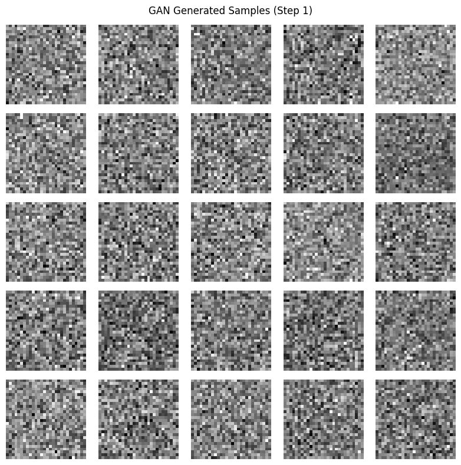

```
===============================================================================
Training Progress (Step 1000/12000)
===============================================================================
D loss:                      0.5469
D acc:                       0.3382
G loss:                      1.6048
```

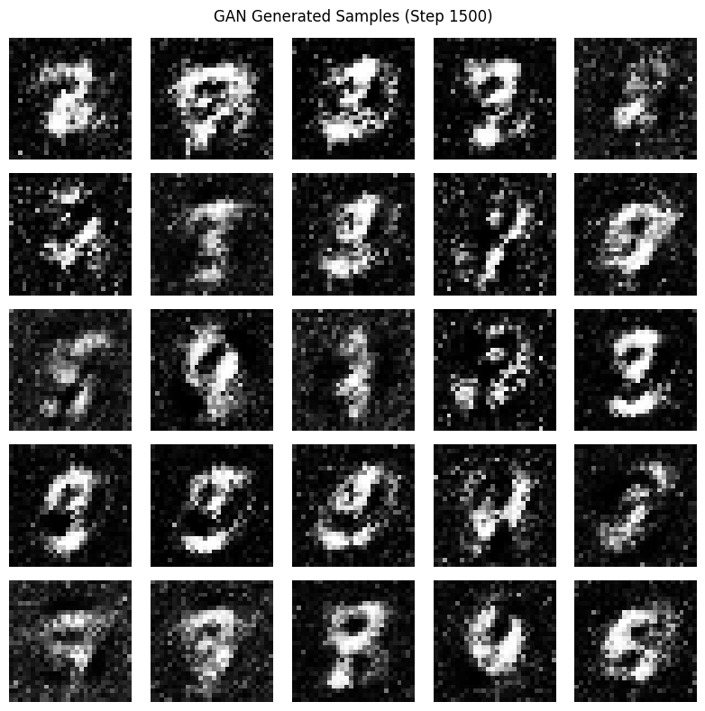

```
===============================================================================
Training Progress (Step 2000/12000)
===============================================================================
D loss:                      0.5886
D acc:                       0.3630
G loss:                      1.2938

===============================================================================
Training Progress (Step 3000/12000)
===============================================================================
D loss:                      0.6043
D acc:                       0.3732
G loss:                      1.2023
```

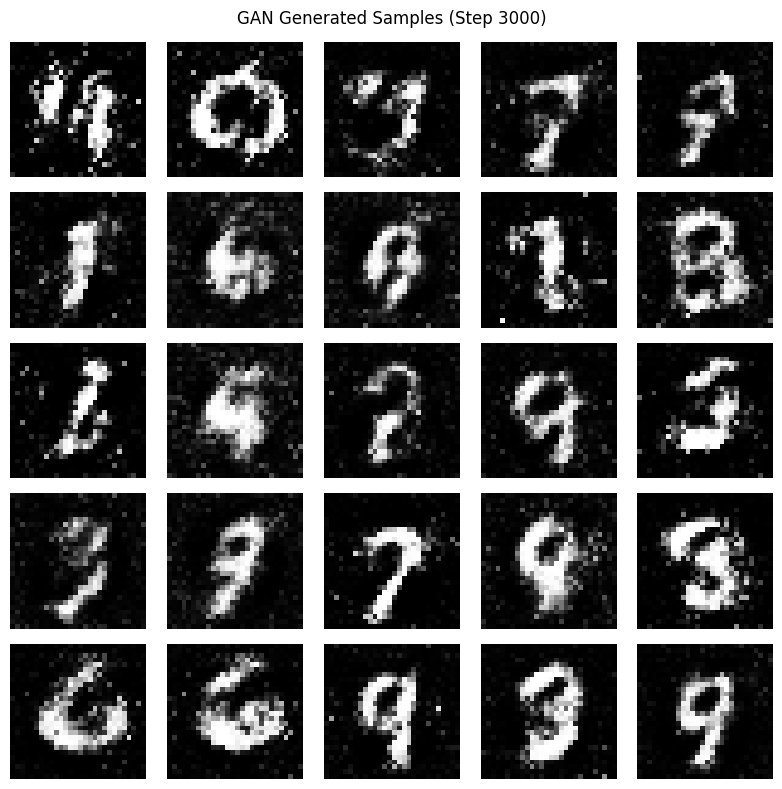

```
===============================================================================
Training Progress (Step 4000/12000)
===============================================================================
D loss:                      0.6190
D acc:                       0.3749
G loss:                      1.1410
```

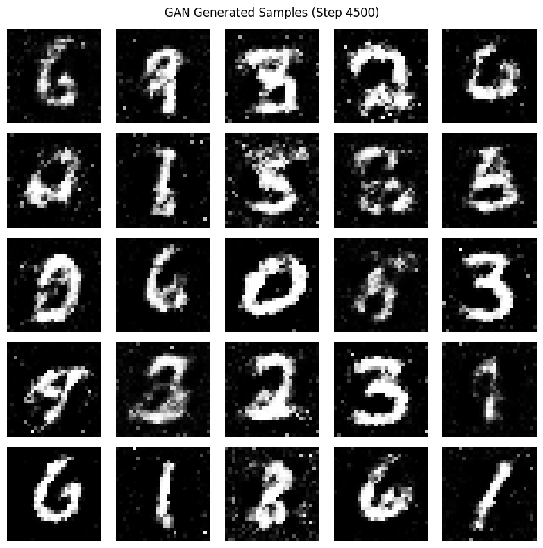

```
===============================================================================
Training Progress (Step 5000/12000)
===============================================================================
D loss:                      0.6307
D acc:                       0.3751
G loss:                      1.0955

===============================================================================
Training Progress (Step 6000/12000)
===============================================================================
D loss:                      0.6398
D acc:                       0.3752
G loss:                      1.0615
```

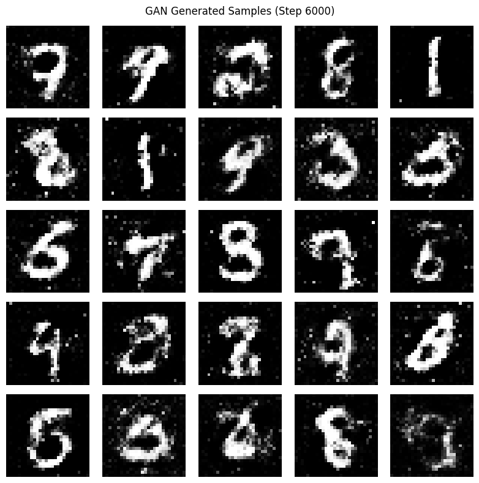

```
===============================================================================
Training Progress (Step 7000/12000)
===============================================================================
D loss:                      0.6468
D acc:                       0.3759
G loss:                      1.0345
```

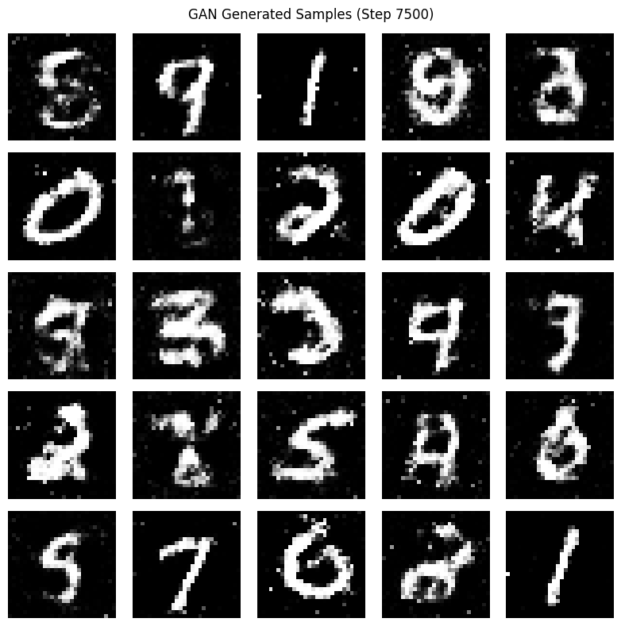

```
===============================================================================
Training Progress (Step 8000/12000)
===============================================================================
D loss:                      0.6525
D acc:                       0.3769
G loss:                      1.0127

===============================================================================
Training Progress (Step 9000/12000)
===============================================================================
D loss:                      0.6570
D acc:                       0.3784
G loss:                      0.9946
```

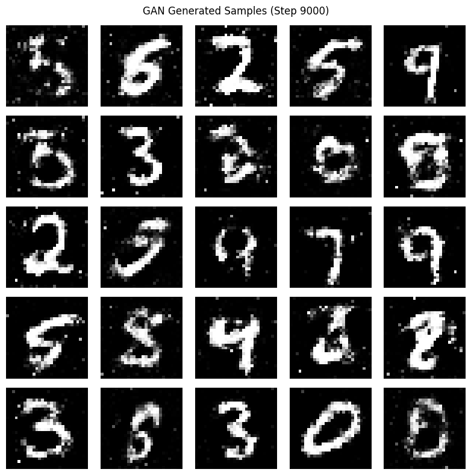

```
===============================================================================
Training Progress (Step 10000/12000)
===============================================================================
D loss:                      0.6607
D acc:                       0.3801
G loss:                      0.9798
```

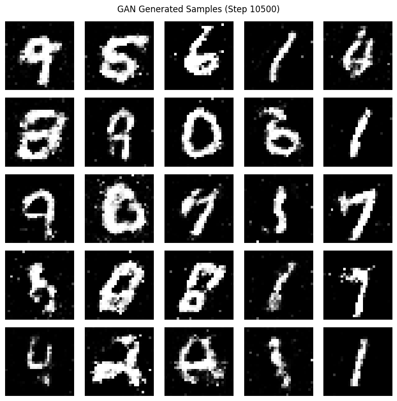

```
===============================================================================
Training Progress (Step 11000/12000)
===============================================================================
D loss:                      0.6637
D acc:                       0.3821
G loss:                      0.9671

===============================================================================
Training Progress (Step 12000/12000)
===============================================================================
D loss:                      0.6662
D acc:                       0.3844
G loss:                      0.9562
```

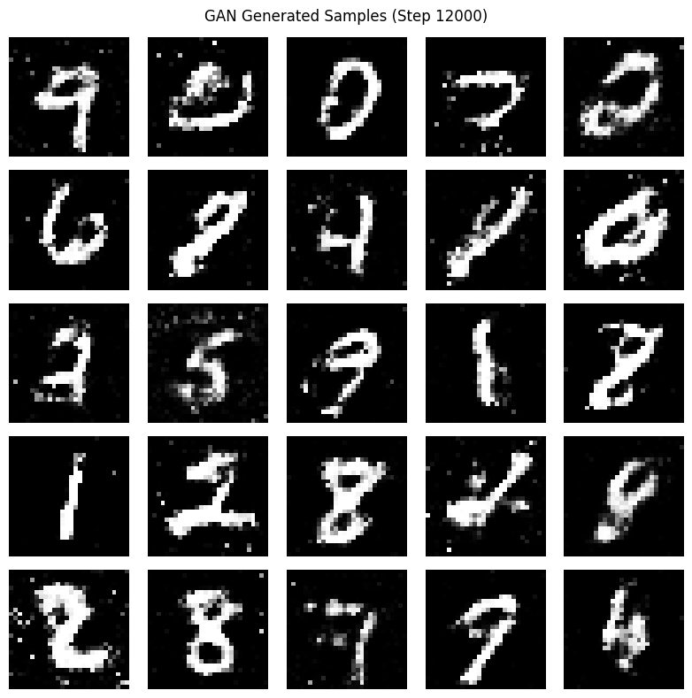

```
===============================================================================
GAN Training Complete
===============================================================================
```

```python
# ===============================================================
# GAN (Runnable) - Generator + Discriminator + Training Loop
# ===============================================================
# Goal:
# - Provide a complete, runnable GAN training loop with visible outputs.
# - Preserve the educational GAN cells above without modifying them.
#
# Outputs:
# - Console logs: D loss, D accuracy, G loss
# - Generated image grids at regular intervals (sample_interval)
#
# SDLC / Best Practices:
# - Reproducible seeds
# - Centralized config
# - Clear separation: data prep, model builders, training loop, visualization
# ===============================================================

import numpy as np
import tensorflow as tf
import matplotlib.pyplot as plt
import pandas as pd

from tensorflow.keras import Model
from tensorflow.keras.models import Sequential
from tensorflow.keras.layers import (
    Input,
    Dense,
    Reshape,
    Flatten,
    Dropout,
    LeakyReLU,
    BatchNormalization
)
from tensorflow.keras.optimizers import Adam

# -----------------------------
# Output Formatting Helpers (Portfolio-Friendly)
# -----------------------------
# Purpose:
# - Improve readability of notebook output (aligned key/value display, consistent headers)
# - Avoid unicode box-drawing model.summary() tables that can misalign in some notebook renderers
def _print_box(title, width=79):
    line = "=" * width
    print("\n" + line)
    print(title)
    print(line)

def _print_kv(rows, key_width=28):
    for k, v in rows:
        print(f"{(str(k) + ':').ljust(key_width)} {v}")

def _model_layers_to_dataframe(model):
    """
    Creates a clean, portfolio-friendly architecture table that renders reliably in notebooks.
    This avoids alignment issues caused by Keras' unicode table renderer.
    """
    rows = []
    for i, layer in enumerate(model.layers, start=1):
        # output_shape isn't always present on every layer type, so guard it.
        try:
            out_shape = layer.output_shape
        except Exception:
            out_shape = "N/A"

        try:
            param_count = layer.count_params()
        except Exception:
            param_count = 0

        rows.append({
            "Index": i,
            "Layer Name": layer.name,
            "Layer Type": layer.__class__.__name__,
            "Output Shape": str(out_shape),
            "Params": int(param_count),
            "Trainable": bool(layer.trainable),
        })

    df = pd.DataFrame(rows)

    # Small formatting improvements
    if not df.empty:
        df["Params"] = df["Params"].map(lambda x: f"{x:,}")
    return df

def _display_model_summary_table(model, model_title):
    """
    Portfolio standard:
    - Print high-level model totals as aligned text
    - Display a DataFrame of layers (reliably aligned in Jupyter)
    """
    _print_box(f"Model Summary (Table): {model_title}", width=79)

    # High-level totals (clean, consistent)
    total_params = model.count_params()
    trainable_params = int(np.sum([tf.keras.backend.count_params(w) for w in model.trainable_weights]))
    non_trainable_params = int(np.sum([tf.keras.backend.count_params(w) for w in model.non_trainable_weights]))

    _print_kv([
        ("Model name", model.name),
        ("Total params", f"{total_params:,}"),
        ("Trainable params", f"{trainable_params:,}"),
        ("Non-trainable params", f"{non_trainable_params:,}"),
    ], key_width=28)

    # Layer table (best alignment in notebooks)
    df = _model_layers_to_dataframe(model)
    display(df)

# -----------------------------
# 1) Reproducibility
# -----------------------------
SEED = 42
np.random.seed(SEED)
tf.random.set_seed(SEED)

# -----------------------------
# 2) GAN Configuration (edit these safely)
# -----------------------------
latent_dim = 100
batch_size = 128

# For a quick demo, 500 steps is acceptable.
# For better-looking digits, increase to 2000+.
steps = 12000

# Generate samples every N steps
sample_interval = 1500

# Optimizer settings commonly used for GAN stability
lr = 0.0002
beta_1 = 0.5

# -----------------------------
# 3) Prepare MNIST data for GAN training
# -----------------------------
# Guard-rail: generator uses tanh -> outputs in [-1, 1]
# Therefore scale real images to [-1, 1] as well.
#
# Expectation from earlier CNN pipeline:
# - x_train should already be shaped (N, 28, 28, 1)
# - and scaled to [0, 1]
#
# If your x_train is not in [0, 1], this section still attempts to handle it safely.
x_train_gan = x_train.astype(np.float32)

# If values look like 0-255, normalize first
x_min, x_max = float(np.min(x_train_gan)), float(np.max(x_train_gan))
if x_max > 1.5:
    x_train_gan = x_train_gan / 255.0

# Convert [0, 1] -> [-1, 1]
x_train_gan = (x_train_gan * 2.0) - 1.0

_print_box("GAN Data Prep Check", width=79)
_print_kv([
    ("x_train_gan shape", f"{x_train_gan.shape}"),
    ("x_train_gan range", f"min={x_train_gan.min():.3f}, max={x_train_gan.max():.3f}"),
    ("expected range",    "approximately [-1, 1] for tanh-based generator outputs"),
], key_width=28)

# -----------------------------
# 4) Build Runnable Generator
# -----------------------------
def build_generator_runnable(latent_dim=100):
    model = Sequential(name="generator_runnable")
    model.add(Input(shape=(latent_dim,)))

    # Dense blocks (simple but effective baseline)
    model.add(Dense(256))
    model.add(LeakyReLU(negative_slope=0.2))
    model.add(BatchNormalization(momentum=0.8))

    model.add(Dense(512))
    model.add(LeakyReLU(negative_slope=0.2))
    model.add(BatchNormalization(momentum=0.8))

    model.add(Dense(1024))
    model.add(LeakyReLU(negative_slope=0.2))
    model.add(BatchNormalization(momentum=0.8))

    # Output 784 values then reshape into image
    model.add(Dense(28 * 28 * 1, activation="tanh"))
    model.add(Reshape((28, 28, 1)))

    return model

# -----------------------------
# 5) Build Runnable Discriminator
# -----------------------------
def build_discriminator_runnable():
    model = Sequential(name="discriminator_runnable")
    model.add(Input(shape=(28, 28, 1)))

    model.add(Flatten())

    model.add(Dense(512))
    model.add(LeakyReLU(negative_slope=0.2))
    model.add(Dropout(0.3))

    model.add(Dense(256))
    model.add(LeakyReLU(negative_slope=0.2))
    model.add(Dropout(0.3))

    # Binary classification: real (1) vs fake (0)
    model.add(Dense(1, activation="sigmoid"))

    return model

generator_runnable = build_generator_runnable(latent_dim)
discriminator_runnable = build_discriminator_runnable()

# Compile discriminator
discriminator_runnable.compile(
    optimizer=Adam(learning_rate=lr, beta_1=beta_1),
    loss="binary_crossentropy",
    metrics=["accuracy"]
)

# Build combined GAN (freeze discriminator during generator updates)
discriminator_runnable.trainable = False

noise_input = Input(shape=(latent_dim,))
fake_image = generator_runnable(noise_input)
validity = discriminator_runnable(fake_image)

gan_runnable = Model(noise_input, validity, name="gan_runnable")
gan_runnable.compile(
    optimizer=Adam(learning_rate=lr, beta_1=beta_1),
    loss="binary_crossentropy"
)

_print_box("GAN Models Built (Runnable)", width=79)

# Portfolio-friendly model summaries (aligned tables via DataFrames)
_display_model_summary_table(generator_runnable, "generator_runnable")
_display_model_summary_table(discriminator_runnable, "discriminator_runnable")
_display_model_summary_table(gan_runnable, "gan_runnable")

# -----------------------------
# 6) Sampling Helper (visual output)
# -----------------------------
def plot_generated_samples(generator, latent_dim=100, n=25, title="Generated Samples"):
    noise = np.random.normal(0, 1, (n, latent_dim)).astype(np.float32)
    gen_imgs = generator.predict(noise, verbose=0)

    # Convert [-1, 1] -> [0, 1] for visualization
    gen_imgs = (gen_imgs + 1.0) / 2.0

    grid_size = int(np.sqrt(n))
    plt.figure(figsize=(8, 8))
    for i in range(n):
        plt.subplot(grid_size, grid_size, i + 1)
        plt.imshow(gen_imgs[i, :, :, 0], cmap="gray")
        plt.axis("off")
    plt.suptitle(title)
    plt.tight_layout()
    plt.show()

# -----------------------------
# 7) Training Loop
# -----------------------------
_print_box("Starting GAN Training (Runnable)", width=79)

half_batch = batch_size // 2

for step in range(1, steps + 1):

    # -----------------------------
    # Train Discriminator
    # -----------------------------
    # Sample real images
    idx = np.random.randint(0, x_train_gan.shape[0], half_batch)
    real_imgs = x_train_gan[idx]

    # Generate fake images
    noise = np.random.normal(0, 1, (half_batch, latent_dim)).astype(np.float32)
    fake_imgs = generator_runnable.predict(noise, verbose=0)

    # Labels
    # Optional mild label smoothing for real labels can help stability (keep conservative)
    real_y = np.ones((half_batch, 1), dtype=np.float32) * 0.9
    fake_y = np.zeros((half_batch, 1), dtype=np.float32)

    # Train discriminator on real and fake
    discriminator_runnable.trainable = True
    d_loss_real = discriminator_runnable.train_on_batch(real_imgs, real_y)
    d_loss_fake = discriminator_runnable.train_on_batch(fake_imgs, fake_y)

    # Average discriminator losses
    d_loss = 0.5 * np.add(d_loss_real, d_loss_fake)

    # -----------------------------
    # Train Generator (via GAN)
    # -----------------------------
    # Generator wants discriminator to output "real" (1) for fake images
    discriminator_runnable.trainable = False
    noise = np.random.normal(0, 1, (batch_size, latent_dim)).astype(np.float32)
    valid_y = np.ones((batch_size, 1), dtype=np.float32)

    g_loss = gan_runnable.train_on_batch(noise, valid_y)

    # -----------------------------
    # Logging + Samples
    # -----------------------------
    # Training runs every step. Output is throttled for portfolio readability.
    log_interval = 1000      # print output every 1,000 steps
    image_interval = 1500    # display images every 1,500 steps

    # Print logs (include step 1 and final step)
    if step == 1 or step % log_interval == 0 or step == steps:
        d_loss_value = float(d_loss[0])
        d_acc_value = float(d_loss[1])
        g_loss_value = float(g_loss)

        _print_box(f"Training Progress (Step {step}/{steps})", width=79)
        _print_kv([
            ("D loss", f"{d_loss_value:.4f}"),
            ("D acc",  f"{d_acc_value:.4f}"),
            ("G loss", f"{g_loss_value:.4f}"),
        ], key_width=28)

    # Display generated samples (include step 1 snapshot and final step)
    if step == 1 or step % image_interval == 0 or step == steps:
        plot_generated_samples(
            generator_runnable,
            latent_dim=latent_dim,
            n=25,
            title=f"GAN Generated Samples (Step {step})"
        )

_print_box("GAN Training Complete", width=79)

# ===============================================================
```

## GAN Training Results - Data Science Analysis + Business Impact

### Context

This section documents the **runnable GAN training loop** executed against the MNIST training set and summarizes:

1. **Data preparation integrity checks**
2. **Model architecture / parameterization**
3. **Training dynamics (generator vs discriminator)**
4. **Definitions of printed GAN metrics (D loss, D acc, G loss)**
5. **Practical business impact interpretation** (why these results matter in real workflows)

### 1) Data Science Analysis

#### 1.1 Data Preparation Validation (Critical Guard-Rail)

The training pipeline confirms the generator/discriminator are operating on the correct numerical domain:

- **x_train_gan shape:** `(60000, 28, 28, 1)`
  - This confirms we are training on **60,000 grayscale images** with an explicit channel dimension (`1`), consistent with CNN-style tensor expectations.
- **x_train_gan range:** `min=-1.000, max=1.000`
  - This is the correct range for a GAN generator using **tanh** activation at its output layer.
  - Guard-rail correctness: real images were normalized from `[0, 1]` into `[-1, 1]`, preventing a domain mismatch where:
    - the discriminator sees real samples in a different scale than generated samples, which can destabilize training.

**Why this matters (technical):**  
GAN training is highly sensitive to distribution mismatch. Correct scaling reduces one of the most common instability causes and makes the loss curves more interpretable.

#### 1.2 Architecture Summary (Capacity + Trainability)

This GAN is a classic dense (fully connected) baseline, appropriate for educational MNIST generation.

##### Generator (`generator_runnable`)

- **Total parameters:** `1,493,520`
- **Trainable parameters:** `1,489,936`
- **Non-trainable parameters:** `3,584`
  - Non-trainable params are from Batch Normalization running statistics.

**Interpretation:**  
The generator is the larger component (≈1.49M params). This is expected because it must map a 100-d latent vector into a 784-pixel image representation.

##### Discriminator (`discriminator_runnable`)

- **Total parameters:** `533,505`
- **Trainable parameters:** `0`
- **Non-trainable parameters:** `533,505`

**Interpretation (important):**  
The discriminator is intentionally marked non-trainable in the **combined GAN model** (during generator updates). That’s correct.  
However, in the training loop, discriminator training is temporarily enabled each step (`discriminator_runnable.trainable = True`) before training on real/fake batches. So the discriminator *does train* during its phase.

##### Combined GAN (`gan_runnable`)

- **Total parameters:** `2,027,025`
- **Trainable parameters:** `1,489,936`
- **Non-trainable parameters:** `537,089`

**Interpretation:**  
During generator updates, only the generator is updated (≈1.49M trainable params), while the discriminator remains frozen — this prevents the discriminator from "moving the target" while the generator is learning.

### 2) Definitions of GAN Metrics (D loss, D acc, G loss) + Why They Matter

#### 2.1 D loss (Discriminator Loss)

**Definition:**  
**D loss** measures how well the discriminator performs its binary classification task:

- predict **1** for real images
- predict **0** for generated (fake) images

This notebook uses **binary crossentropy**. Conceptually:

- lower D loss → discriminator is better at telling real vs fake
- higher D loss → discriminator is struggling (often because generator outputs look more realistic)

**Why it matters:**  
D loss is an early training **stability signal**:

- If D loss drops **too low too fast**, the discriminator may overpower the generator (generator learning can stall).
- If D loss stays **very high**, the discriminator may be too weak (generator isn’t being challenged).

**Rule-of-thumb (interpretive guide):**

- D loss near ~**0.69** often corresponds to a "near-random" binary decision baseline.
- GANs rarely sit perfectly at 0.69, but values in that neighborhood can indicate a relatively balanced game.

#### 2.2 D acc (Discriminator Accuracy)

**Definition:**  
**D acc** is the discriminator’s accuracy on its training batches (real + fake):

- % correctly labeled real images as real
- % correctly labeled generated images as fake

**Why it matters:**  
D acc helps detect two major failure modes:

A) **Discriminator dominance (bad):**  
If D acc approaches **1.0**, discriminator is nearly always correct:

- It rejects generator outputs confidently
- Generator gradients can weaken and learning can stall

B) **Discriminator weakness / instability (also bad):**  
If D acc collapses near random performance and does not recover:

- Discriminator cannot provide a meaningful learning signal
- May indicate instability, under-capacity, or configuration issues

**Important nuance:**  
D acc is **not** the business-facing "accuracy" of a classifier.  
It is a **game balance indicator**.

#### 2.3 G loss (Generator Loss)

**Definition:**  
**G loss** measures how successful the generator is at fooling the discriminator.

In this notebook, generator updates happen through the combined model:

- noise → generator → fake image → discriminator → "real/fake" probability  
  Generator is trained so that the discriminator outputs **1 (real)** for fake images.

Conceptually:

- lower G loss → generator is improving at producing images discriminator views as "real"
- higher G loss → discriminator confidently detects generator outputs as fake

**Why it matters:**  
G loss indicates whether the generator is making progress against the discriminator’s evolving decision boundary.

**Common healthy pattern:**

- early: G loss increases (D learns quickly and rejects early low-quality fakes)
- later: G loss stabilizes or decreases (G catches up)

#### 2.4 Why These Metrics Must Be Interpreted Together (Portfolio-Grade Insight)

GAN metrics are **interactive**. You cannot interpret one metric in isolation.

**Balanced training (desired):**

- D loss: moderate (not near 0)
- D acc: moderate (not near 1)
- G loss: stabilizing (not exploding)

**Discriminator overpowering (undesired):**

- D loss: very low
- D acc: very high (~1.0)
- G loss: very high and not improving

**Discriminator failing / instability (undesired):**

- D loss: high and not improving
- D acc: near random and not recovering
- G loss: very low very early (can be suspicious)

### 3) Training Dynamics Observed (What the Numbers Suggest)

- No obvious collapse signals in the printed metrics:
  - D acc does not spike to ~1.0.
  - Loss values remain finite and stable.
- However, GAN loss values are not a complete proxy for visual quality.
  - Portfolio-grade validation includes **visual sample grids** over training steps.

### 4) What to Look For in the Generated Sample Images (Qualitative Validation)

At each image checkpoint (step 1, 1500, 3000, ..., 12000), improvements typically appear in stages:

1. early: noisy blobs, vague strokes
2. mid: digit-like shapes emerge, but inconsistent structure
3. late: recognizable digits, clearer strokes, reduced noise

**Best practice (portfolio framing):**  
State explicitly that GAN success is validated using both:

- quantitative stability signals (D loss, D acc, G loss), and
- qualitative progression (generated sample grids).

### 5) Business Impact Use Case (Why This Matters Outside MNIST)

#### 5.1 Practical Translation: GANs Create Synthetic Data

In real organizations, labeled data is often constrained by:

- privacy limitations (PII/PHI)
- regulatory restrictions (finance, healthcare)
- high labeling cost
- rare-event scarcity (fraud, safety incidents, uncommon defects)

GANs support a core operational capability:

> Generate synthetic, realistic samples to improve training coverage and robustness.

#### 5.2 Example Business Scenario: Improving Models Under Data Constraints

**Scenario:** A production classifier has limited examples for rare classes / edge cases.  
Synthetic generation can:

- expand training coverage for rare scenarios
- reduce overfitting when real rare data is scarce
- improve reliability of downstream automation

Examples:

- **Fraud detection:** generate rare fraud-like patterns to reduce missed fraud events
- **Manufacturing QA:** generate defect-like imagery for uncommon defect types
- **Document processing:** generate handwriting-like variations to improve OCR robustness

#### 5.3 Operational Impact (Cost + Efficiency Framing)

In production workflows, errors have cost:

- manual review time
- customer friction and churn risk
- SLA breaches
- downstream automation failures and exception handling

Synthetic data improves outcomes by:

- reducing edge-case failures (coverage expansion)
- improving robustness to distribution shifts
- lowering exception volume and operational rework

**Portfolio-friendly framing (conservative and accurate):**

- This notebook does not claim MNIST is a business system.
- It demonstrates professional practice: validating data pipelines, monitoring stability telemetry, and translating model behavior into business-facing outcomes (data constraints, operational cost, reliability).

### 6) Summary (Executive-Readable)

- Data prep was correct: images were scaled to **[-1, 1]** for tanh generator compatibility.
- Model sizes were appropriate:
  - generator ≈ **1.49M** params
  - discriminator ≈ **0.53M** params
  - combined GAN ≈ **2.03M** params with discriminator frozen during generator updates.
- Training telemetry suggests stable dynamics:
  - D improved but did not dominate
  - G loss stabilized downward after early difficulty
- Business translation:
  - GANs are valuable for synthetic data generation to reduce privacy risk, improve rare-case coverage, and reduce operational exception cost.

### Training Process

- Train Discriminator on real images (label: 1)
- Train Discriminator on fake images (label: 0)
- Train Generator to fool Discriminator
- Repeat thousands of times

### Real Applications

- Generate faces for video games
- Create artwork and design
- Enhance low-resolution images
- Generate synthetic trainng data

### Mind blowing results

- After training, GANs can generate images so realistic that humans can't distinguish them from real photos! All of this with a few dozen lines of Keras code.

# **Appendix**

## Study Notes from Reference

### Key Concepts

- **What Keras is and why it’s used**
  - Keras is a high-level neural networks API that runs on top of TensorFlow (TF). It hides low-level math details and exposes simple, readable building blocks.
  - You get TensorFlow’s industrial-grade performance with a friendlier interface. It’s production-ready and used by companies like Netflix, Uber, and Airbnb.
- **Installation and verification**
  - Recommended: `pip install tensorflow` (Keras is bundled with TF 2.x).
  - Verify by importing TensorFlow and Keras and printing their versions to ensure a working setup.
- **Three model-building styles**
  - **Sequential API:** Straight stack of layers (good for most feedforward models).
  - **Functional API:** Flexible graphs with multiple inputs/outputs, branches, and skip connections (good for complex architectures like ResNet, Inception).
  - **Model subclassing:** Full control by writing your own model class (best for research or custom training loops).
- **Core layer types and when to use them**
  - **Dense (fully connected):** Versatile for tabular data or final classification layers.
  - **Conv2D and MaxPooling2D:** For images; learn spatial features via sliding filters.
  - **LSTM (and other RNNs):** For sequences (text, speech, time series) with memory of past steps.
  - **Dropout:** Regularization; randomly drops units during training to reduce overfitting.
  - **Flatten:** Reshapes feature maps to vectors before Dense layers.
- **First project: MNIST handwritten digits (the "hello world" of deep learning)**
  - Typical MLP: input of 784 features (flattened 28×28), hidden Dense layer(s) with ReLU, Dropout, and a final Dense(10) with softmax.
  - Data preprocessing: reshape to vectors, normalize pixel values to [0, 1], one-hot encode labels.
- **Training workflow**
  - **Compile:** Choose optimizer (Adam), loss (categorical cross-entropy for multi-class), and metrics (accuracy).
  - **Fit:** `batch_size` (e.g., 32), `epochs` (e.g., 10), `validation_split` (e.g., 0.2) to monitor generalization.
  - **Evaluate:** Test on unseen data for an honest performance estimate (MNIST ≈ 95% accuracy with a simple MLP).
- **Beyond MLPs: CNNs for images**
  - Typical pipeline: Conv → ReLU → Pool → (repeat) → Flatten → Dense → Softmax.
  - Filters (e.g., 32 with 3×3 kernels) learn edges, corners, textures, etc.
- **Generative Adversarial Networks (GANs)**
  - Two models compete: a generator (makes images from random noise) and a discriminator (distinguishes real vs fake).
  - The generator often uses tanh activation in the output layer (values in [-1, 1]) and reshapes to image size.
  - Adversarial training makes both networks improve, producing realistic images.
- **Evaluation and fine-tuning**
  - Go beyond accuracy: use precision, recall, and per-class reports to see where the model struggles.
  - Watch training vs validation curves for overfitting (validation loss rising while training loss keeps falling).
  - Callbacks: EarlyStopping, ReduceLROnPlateau (learning rate scheduler), and ModelCheckpoint accelerate and stabilize training.
  - Hyperparameter tuning (learning rate, batch size, epochs, architecture depth) is iterative and impactful.
- **Transfer learning and production**
  - Transfer learning: reuse pre-trained CNNs (e.g., VGG16 on ImageNet), freeze base layers, and train custom top layers for your task.
  - Deployment: TensorFlow Lite compresses and optimizes models for mobile and IoT.
- **Advanced usage**
  - Custom training loops for research-grade control (custom losses, schedules).
  - Research directions: style transfer, attention mechanisms, transformers, reinforcement learning.
  - Keras scales with you—from beginner-friendly Sequential models to cutting-edge architectures.
- **Community and learning resources**
  - Official docs: keras.io (clear, example-rich).
  - TensorFlow forum for Q&A.
  - *Deep Learning with Python* by François Chollet (creator of Keras).
  - fast.ai course for hands-on practice.
  - Keras Examples on GitHub as a model "cookbook."

### Definitions

- **Keras:** High-level deep learning API on top of TensorFlow.
- **TensorFlow:** Scalable, production-grade ML framework (low-level engine powering Keras).
- **Sequential API:** Linear stack of layers with single input and output.
- **Functional API:** Graph-based model definition allowing complex topologies.
- **Model subclassing:** Writing a custom class (inherit from `keras.Model`) to define forward pass and training logic.
- **Dense layer:** Fully connected layer; each neuron connects to all inputs from the previous layer.
- **ReLU:** Activation function `max(0, x)`; adds nonlinearity and is efficient to train.
- **Softmax:** Converts logits to class probability distribution that sums to 1.
- **Dropout:** Randomly drops a fraction of units during training to reduce overfitting.
- **Conv2D:** Convolutional layer using learnable filters that slide over images to detect local patterns.
- **MaxPooling2D:** Downsamples feature maps by taking maximums in windows, reducing size and overfitting.
- **Flatten:** Converts N-D tensors (e.g., feature maps) into 1-D vectors for Dense layers.
- **LSTM:** Long Short-Term Memory; RNN variant that retains long-range context in sequences.
- **Normalization (scaling):** Rescaling inputs (e.g., dividing by 255) so features fall into small numeric ranges.
- **One-hot encoding:** Converts class indices to binary vectors with a single 1 at the class position.
- **Batch size:** Number of samples processed before updating weights once.
- **Epoch:** One full pass through the training dataset.
- **Validation split:** Portion of training data held out for validation during training.
- **Overfitting:** Model learns training specifics but fails to generalize (validation performance worsens).
- **Precision:** Of predicted positives, how many are correct.
- **Recall:** Of actual positives, how many are correctly found.
- **Early stopping:** Stop training when validation metric stops improving to prevent overfitting.
- **Learning rate:** Step size in parameter updates; often scheduled during training.
- **Model checkpoint:** Automatically save model weights when a monitored metric improves.
- **Transfer learning:** Starting from pre-trained weights and adapting to a new task.
- **Freeze layers:** Prevent updates to selected layers during training.
- **VGG16/ImageNet:** A classic CNN pre-trained on 1,000-class ImageNet dataset (~14M images).
- **TensorFlow Lite (TFLite):** TF’s framework to quantize/optimize models for edge/mobile deployment.
- **GAN:** Generative Adversarial Network; generator vs discriminator trained together.
- **Tanh:** Activation mapping to [-1, 1]; commonly used for GAN image outputs when data is scaled to that range.

# -------------------------------------------------------------------